# EDA Cart Abandonment

Author

Ethan Aslami, Riley Walburger, Tara Connin

Published

October 5, 2025

# 1 🎯 Business Problem Statement

## 1.1 Business Problem

Swire Coca-Cola operates the MyCoke360 platform to streamline business-to-business ordering and improve digital engagement. Despite strong platform adoption, many customers add items to their carts but fail to complete purchases before the order cutoff time. These incomplete transactions, known as cart abandonment, reduce potential revenue and signal inefficiencies in the online ordering process.

The company seeks to better understand the factors associated with incomplete purchases in order to improve conversion rates and enhance the performance of its e-commerce platform. By examining customer activity and purchase behavior within MyCoke360, patterns can be identified that distinguish completed orders from those that are abandoned, providing a foundation for data-driven strategies to improve order completion.

## 1.2 Analytic Problem

The analytic challenge is to transform raw behavioral and transactional data into a reliable view of customer purchase behavior. Google Analytics captures event-level activity such as “add_to_cart,” “remove_from_cart,” and “purchase,” but does not record a running cart total. Therefore, the analysis must reconstruct each customer’s cart over time to determine whether the customer purchased the items before their cutoff date or left them unpurchased. A binary target variable will be created to indicate whether a customer failed to complete a purchase (1) or successfully converted (0) within an order window. Exploratory analysis will then identify patterns and predictors of abandonment, including device type, number of cart interactions, timing of last activity, item categories, and delivery frequency. This will provide the foundation for predictive and behavioral models that quantify the likelihood of cart abandonment and inform interventions to reduce it.

# 2 🛠️ Setup

- Read in Files
- Load Libraries
- Clean some of the data

**🖱️👆 Click to Show Code**

```r
# Load Libraries
library(tidyverse)
library(janitor)
library(caret)
library(data.table)
library(knitr)
library(kableExtra)
library(scales)

# We need to create a new dataset that uses the google analytics and the order table to create each row as a unique
# visit to the website, we will be able to tell maybe using date and time to see if they purchased or abandoned
```

## 2.1 Load data

**🖱️👆 Click to Show Code**

```r
# some minimal cleaning here as well

customer <- fread("C:/Users/Ethan/OneDrive - University of Utah/MSBA Program/Final Capstone Swire/data/customer.csv") |>
  clean_names() |>
  rename(customer_id = customer_number, # match google analytics
         plant_id = sales_office) # match the orders table and cutoff table

# Fix the cutoff time to the same date format as the GA table
cutoff_times <- fread("C:/Users/Ethan/OneDrive - University of Utah/MSBA Program/Final Capstone Swire/data/cutoff_times.csv") |>
  clean_names()

material <- fread("C:/Users/Ethan/OneDrive - University of Utah/MSBA Program/Final Capstone Swire/data/material.csv") |>
  clean_names()

# Fix a few names
operating_hours <- fread("C:/Users/Ethan/OneDrive - University of Utah/MSBA Program/Final Capstone Swire/data/operating_hours.csv") |>
  clean_names() |>
  rename(customer_id = customer_number,
         frequency_weeks =  frequency) # match names for a join later

orders <- fread("C:/Users/Ethan/OneDrive - University of Utah/MSBA Program/Final Capstone Swire/data/orders.csv") |>
  clean_names()

sales <- fread("C:/Users/Ethan/OneDrive - University of Utah/MSBA Program/Final Capstone Swire/data/sales.csv") |>
  clean_names()

# Clean up the frequency column
visit_plan <- fread("C:/Users/Ethan/OneDrive - University of Utah/MSBA Program/Final Capstone Swire/data/visit_plan.csv") |>
  clean_names() |>
  rename(plant_id = sales_office,
         distribution_mode_key = distribution_mode)

google_analytics <- fread("C:/Users/Ethan/OneDrive - University of Utah/MSBA Program/Final Capstone Swire/data/google_analytics.csv") |>
  clean_names()
```

## 2.2 Clean visit plan and cutoff_times

**🖱️👆 Click to Show Code**

```r
# Create frequency_weeks column to match the operating hours table
visit_plan[frequency %in% c("01", "Every Week On", "1"), frequency_weeks := "Every Week"]
visit_plan[frequency %in% c("02", "Every Second Week On", "2"), frequency_weeks := "Every 2 Weeks"]
visit_plan[frequency %in% c("03", "Every Third Week On", "3"), frequency_weeks := "Every 3 Weeks"]
visit_plan[frequency %in% c("04", "Every Fourth Week On", "4"), frequency_weeks := "Every 4 Weeks"]

# Create distribution mode description column to match the other tables formatting
visit_plan[distribution_mode_key %in% c("SL"), distribution_mode_description := "Sideload"]
visit_plan[distribution_mode_key %in% c("OF"), distribution_mode_description := "OFS"]
visit_plan[distribution_mode_key %in% c("EZ"), distribution_mode_description := "EZ Pallet"]
visit_plan[distribution_mode_key %in% c("RD"), distribution_mode_description := "Rapid Delivery"]
visit_plan[distribution_mode_key %in% c("NR"), distribution_mode_description := "Night Rapid Delivery"]
visit_plan[distribution_mode_key %in% c("FS"), distribution_mode_description := "Full Service"]
visit_plan[distribution_mode_key %in% c("BK"), distribution_mode_description := "Bulk Distribution"]
visit_plan[distribution_mode_key %in% c("SE"), distribution_mode_description := "Special Events"]
visit_plan[distribution_mode_key %in% c("NS"), distribution_mode_description := "Night Side Load"]
visit_plan[distribution_mode_key %in% c("NO"), distribution_mode_description := "Night OFS"]
visit_plan[distribution_mode_key %in% c("DD"), distribution_mode_description := ""]
visit_plan[distribution_mode_key %in% c("null", ""), distribution_mode_description := ""]

# a few of these for cutoff_times as well
cutoff_times[distribution_mode %in% c("Night Sideload"), distribution_mode_description := "Night Side Load"]
cutoff_times[distribution_mode %in% c("OFS"), distribution_mode_description := "OFS"]
cutoff_times[distribution_mode %in% c("E Pallet"), distribution_mode_description := "EZ Pallet"]
cutoff_times[distribution_mode %in% c("Nights Bulk"), distribution_mode_description := "Nights Bulk"]
cutoff_times[distribution_mode %in% c("Tell Sell"), distribution_mode_description := "Tell Sell"]
cutoff_times[distribution_mode %in% c("Sideload"), distribution_mode_description := "Sideload"]
cutoff_times[distribution_mode %in% c("Night Rapid Delivery"), distribution_mode_description := "Night Rapid Delivery"]
cutoff_times[distribution_mode %in% c("Full Service"), distribution_mode_description := "Full Service"]
cutoff_times[distribution_mode %in% c("Bulk Distribution"), distribution_mode_description := "Bulk Distribution"]
cutoff_times[distribution_mode %in% c("Special Events"), distribution_mode_description := "Special Events"]
cutoff_times[distribution_mode %in% c("Night OFS"), distribution_mode_description := "Night OFS"]
cutoff_times[distribution_mode %in% c("Rapid Delivery"), distribution_mode_description := "Rapid Delivery"]

# Update the values for shipping condition desc
visit_plan[shipping_conditions_desc %in% c("24 Hours", "Dropsite 24 Hours"), shipping_condition_time := "24hrs"]
visit_plan[shipping_conditions_desc %in% c("48 Hours", "Dropsite 48 Hours"), shipping_condition_time := "48hrs"]
visit_plan[shipping_conditions_desc %in% c("72 Hours", "Dropsite 72 Hours"), shipping_condition_time := "72hrs"]
```

## 2.3 Join cutoff_times and visit_plan

**🖱️👆 Click to Show Code**

```r
# set keys for both tables
setkey(cutoff_times, plant_id, shipping_condition_time, distribution_mode_description)
setkey(visit_plan,   plant_id, shipping_condition_time, distribution_mode_description)

# perform the join (left join by default)
visit_plan_joined <- cutoff_times[visit_plan]

# set any missing cutoff_times to 5pm (This is what kurt said to do)
visit_plan_joined[is.na(cutofftime_c), cutofftime_c := "5:00:00 PM"]
# Parse into POSIXct (time only, we don't care about the date part on this one)
visit_plan_joined[, cutofftime_posix := parse_date_time(cutofftime_c, orders = "I:M:S p")]

# There are some empty rows after the join that we set to 5pm here, this happens because of the missing Tell Sell distribution mode
# This exists in the cutoff times but not in the visit plans.
visit_plan_joined[, anchor_date := ymd(anchor_date)]
```

## 2.4 Clean visit plan to only the rows we need

- Remoce a bunch of data outside of the time-frame of the GA data

**🖱️👆 Click to Show Code**

```r
# Filter to relevant date range
visit_plan <- visit_plan[elt_ts >= as.POSIXct("2024-05-31")]

result <- visit_plan[!is.na(anchor_date),
                     .(elt_ts_min = min(elt_ts),
                       elt_ts_max = max(elt_ts)),
                     by = .(customer_id, anchor_date)]
```

## 2.5 Google analytics Cleaning

- Add the time zone fix to make sure everything is in local time for GA data

**🖱️👆 Click to Show Code**

```r
tz_lookup <- data.table(
  state = c("UT", "WA", "CO", "AZ", "OR", "ID", "NV", "NM", "NE", "WY"),
  tz = c(
    "US/Mountain",     # Utah
    "US/Pacific",      # Washington
    "US/Mountain",     # Colorado
    "US/Arizona",      # Arizona (no DST)
    "US/Pacific",      # Oregon
    "US/Mountain",     # Idaho
    "US/Pacific",      # Nevada
    "US/Mountain",     # New Mexico
    "US/Central",      # Nebraska
    "US/Mountain"      # Wyoming
  )
)

# add state column and join tz
customer[, state := sub(".*,\\s*", "", sales_office_description)]
customer <- tz_lookup[customer, on = "state"]

# join tz to GA data
google_analytics <- customer[google_analytics, on = .(customer_id), nomatch=0]

# Manual offsets for all except Arizona
tz_offsets <- data.table(
  tz = c("US/Central", "US/Mountain", "US/Pacific"),
  hour_offset = c(1, 2, 3)
)

# Join offsets
google_analytics <- tz_offsets[google_analytics, on = "tz"]

# Add POSIXct EST timestamp
google_analytics[, event_ts_est := ymd_hms(event_timestamp, tz = "America/New_York")]

# Handle Arizona separately
google_analytics[tz == "US/Arizona",
  hour_offset := ifelse(dst(event_ts_est), 3, 2)] # checks if daylight savings is active and works accordingly

# Apply manual hour offset
google_analytics[, event_ts_local := event_ts_est - dhours(hour_offset)]

# Show one sample per timezone
google_analytics[, .(
  sample_est = head(event_ts_est, 2),
  sample_local = head(event_ts_local, 2)
), by = tz]
```

```
            tz          sample_est        sample_local
        <char>              <POSc>              <POSc>
1: US/Mountain 2025-04-07 14:57:40 2025-04-07 12:57:40
2: US/Mountain 2025-04-07 19:28:54 2025-04-07 17:28:54
3:  US/Pacific 2025-04-07 21:40:56 2025-04-07 18:40:56
4:  US/Pacific 2025-04-09 22:29:38 2025-04-09 19:29:38
5:  US/Arizona 2025-04-08 18:12:10 2025-04-08 15:12:10
6:  US/Arizona 2025-04-05 15:42:12 2025-04-05 12:42:12
7:  US/Central 2025-05-07 16:08:12 2025-05-07 15:08:12
8:  US/Central 2025-03-31 19:58:10 2025-03-31 18:58:10
```

**🖱️👆 Click to Show Code**

```r
# Also check unique time zones
unique(google_analytics$tz)
```

```
[1] "US/Mountain" "US/Pacific"  "US/Arizona"  "US/Central"
```

# 3 ⏱️ Create the Order Window

- This is our attempt at getting closer to the target variable of cart abandonment by creating the order window.

## 3.1 Cleaning Visit Plan

What section of Visit Plan is needed?

Plan:

- Filter to Snapshot Dates to those after our first Google Analytics Time stamp.
- Filter out Future Plans as these will take place eventually but don’t matter to us right now.
- Group by Customer ID and ELT_TS
  - In other words we are getting a table for every unique time the customer changed their plan.
- From here we will break out the customer unique plans into their order windows.

**🖱️👆 Click to Show Code**

```r
# Match riley's df names to the ones in this document

df_visit_plan <- fread("C:/Users/Ethan/OneDrive - University of Utah/MSBA Program/Final Capstone Swire/data/visit_plan.csv")

df_google_analytics <- fread("C:/Users/Ethan/OneDrive - University of Utah/MSBA Program/Final Capstone Swire/data/google_analytics.csv")


head(df_visit_plan)
```

```
   CUSTOMER_ID FREQUENCY              ELT_TS SNAPSHOT_DATE ANCHOR_DATE
         <int>    <char>              <POSc>        <IDat>      <char>
1:   500405850        02 2021-12-14 05:49:54    2021-12-13  2020-07-20
2:   500286563        01 2021-12-14 05:49:54    2021-12-13  2019-11-04
3:   600057832        01 2021-12-14 05:49:54    2021-12-13  2021-08-02
4:   500431853        01 2021-12-14 05:49:54    2021-12-13  2020-04-06
5:   600076074        01 2021-12-14 05:49:54    2021-12-13  2019-06-07
6:   600057023        02 2021-12-14 05:49:54    2021-12-13  2020-04-13
   SALES_OFFICE    SALES_OFFICE_DESC DISTRIBUTION_MODE SHIPPING_CONDITIONS_DESC
         <char>               <char>            <char>                   <char>
1:         G133 Glenwood Springs, CO                SL                 48 Hours
2:         G236           Denver, CO                OF                 48 Hours
3:         G111           Draper, UT                SL                 48 Hours
4:         G111           Draper, UT                SL                 48 Hours
5:         G142        Pocatello, ID                EZ                 24 Hours
6:         G111           Draper, UT                SL                 48 Hours
```

**🖱️👆 Click to Show Code**

```r
head(df_google_analytics)
```

```
   CUSTOMER_ID EVENT_DATE     EVENT_TIMESTAMP                 EVENT_NAME
         <int>     <IDat>              <POSc>                     <char>
1:   501508595 2025-04-07 2025-04-07 14:57:40        view_search_results
2:   501730915 2025-04-07 2025-04-07 19:28:54             view_item_list
3:   501567329 2025-04-07 2025-04-07 21:40:56                   purchase
4:   501765083 2025-04-08 2025-04-08 06:06:36            user_engagement
5:   501707837 2025-04-08 2025-04-08 18:12:10             view_item_list
6:   501737588 2025-04-07 2025-04-07 21:34:04 ProductsList_PLP_Retrieved
   DEVICE_CATEGORY DEVICE_MOBILE_BRAND_NAME DEVICE_OPERATING_SYSTEM
            <char>                   <char>                  <char>
1:          mobile                  Samsung                 Android
2:         desktop                   Google                 Windows
3:         desktop                   Google                 Windows
4:          mobile                    Apple                     iOS
5:         desktop                   Google                 Windows
```

[output cut: 17 more lines]

**🖱️👆 Click to Show Code**

```r
First_GA_Date <- min(as.Date(df_google_analytics$EVENT_DATE), na.rm = TRUE)

print(First_GA_Date)
```

```
[1] "2024-05-31"
```

We filter out all visit plans that were before this date.

We will also filter out plans that are upcoming. We don’t care about them until they actually take place in this record.

**🖱️👆 Click to Show Code**

```r
df_visit_plan_filtered <- df_visit_plan %>%
  filter(
    SNAPSHOT_DATE > First_GA_Date,           # Keep rows after first GA date
    SNAPSHOT_DATE >= as.Date(ANCHOR_DATE)    # Remove rows before anchor_date (future plans)
  )
```

**🖱️👆 Click to Show Code**

```r
# Row count of the original data
nrow(df_visit_plan)
```

```
[1] 13638682
```

**🖱️👆 Click to Show Code**

```r
# Row count of the filtered data
nrow(df_visit_plan_filtered)
```

```
[1] 5147146
```

**🖱️👆 Click to Show Code**

```r
round(nrow(df_visit_plan_filtered) / nrow(df_visit_plan), 2)
```

```
[1] 0.38
```

**🖱️👆 Click to Show Code**

```r
df_specific_customer <- df_visit_plan_filtered %>%
  filter(CUSTOMER_ID == "0500245685")
```

We now to clean out some messy data in a few columns

**🖱️👆 Click to Show Code**

```r
unique(df_visit_plan_filtered$FREQUENCY)
```

```
 [1] "02"                   "01"                   "Every Second Week On"
 [4] "Every Week On"        "Every Third Week On"  "Every Fourth Week On"
 [7] "Every Tenth Week On"  "Every Fifth Week On"  "Every Eighth Week On"
[10] "04"                   "03"                   "Every Sixth Week On"
[13] "Not Applicable"       "1"                    "2"
[16] "4"                    "10"                   "3"
[19] "05"                   "8"                    "08"
[22] "06"
```

**🖱️👆 Click to Show Code**

```r
df_visit_plan_filtered <- df_visit_plan_filtered %>%
  mutate(freq_days = case_when(
    FREQUENCY %in% c("01", "1", "1.0", "Every Week On") ~ 7,
    FREQUENCY %in% c("02", "2", "2.0", "Every Second Week On") ~ 14,
    FREQUENCY %in% c("03", "3", "3.0", "Every Third Week On") ~ 21,
    FREQUENCY %in% c("04", "4", "4.0", "Every Fourth Week On") ~ 28,
    FREQUENCY == "Every Fifth Week On"  ~ 35,
    FREQUENCY == "Every Sixth Week On"  ~ 42,
    FREQUENCY == "Every Eighth Week On" ~ 56,
    FREQUENCY == "Every Tenth Week On"  ~ 70,
    TRUE ~ NA_real_   # default if not matched
  ))
```

**🖱️👆 Click to Show Code**

```r
# Make sure ANCHOR_DATE is Date class
df_visit_plan_filtered$ANCHOR_DATE <- as.Date(df_visit_plan_filtered$ANCHOR_DATE)

# Get day of week as a string
df_visit_plan_filtered$ANCHOR_DOW <- weekdays(df_visit_plan_filtered$ANCHOR_DATE)

# Example output
head(df_visit_plan_filtered$ANCHOR_DOW)
```

```
[1] "Wednesday" "Thursday"  "Tuesday"   "Monday"    "Monday"    "Monday"
```

We will now take this filtered dataset and turn it into a summarized visit plan for each customer.

**🖱️👆 Click to Show Code**

```r
df_visit_plan_summary <- df_visit_plan_filtered %>%
  group_by(CUSTOMER_ID, ANCHOR_DATE) %>%
  summarise(
    across(
      .cols = c(freq_days, SNAPSHOT_DATE,
                SALES_OFFICE, SALES_OFFICE_DESC,
                DISTRIBUTION_MODE, SHIPPING_CONDITIONS_DESC, ELT_TS),
      .fns = list(min = ~min(.x, na.rm = TRUE),
                  max = ~max(.x, na.rm = TRUE)),
      .names = "{.col}_{.fn}"
    ),
    .groups = "drop"
  )
```

Lets do some double checks that we are having some clean data.

**🖱️👆 Click to Show Code**

```r
df_visit_plan_odd <- df_visit_plan_summary %>%
  # keep only rows where at least one column's min != max, excluding SNAPSHOT_DATE
  filter(
    rowSums(
      across(
        ends_with("_min") & !matches("^SNAPSHOT_DATE_min$"),  # exclude SNAPSHOT_DATE_min
        ~ .x != get(sub("_min$", "_max", cur_column()))
      )
    ) > 0
  )
```

We have some cases when Shipping Conditions change and distribution mode changes however we are going to define an order window as staying the same for a customer until it they get a new one per the anchor_date.

**🖱️👆 Click to Show Code**

```r
head(df_visit_plan_summary %>%
  count(CUSTOMER_ID, sort = TRUE))
```

```
# A tibble: 6 × 2
  CUSTOMER_ID     n
        <int> <int>
1   501207602    14
2   501641412    13
3   600685309    12
4   600685860    12
5   600555686    10
6   600585067    10
```

From here on out as they are the mostly the same I will be using the min columns as y final definitions.

**🖱️👆 Click to Show Code**

```r
df_visit_plan_summary_lead <- df_visit_plan_summary %>%
  group_by(CUSTOMER_ID) %>%
  arrange(ANCHOR_DATE, .by_group = TRUE) %>%
  mutate(
    end_plan_date = lead(ANCHOR_DATE),
    next_plan_freq_days = lead(freq_days_min),
    next_plan_dist_mode = lead(DISTRIBUTION_MODE_min),
    next_plan_ship_cond = lead(SHIPPING_CONDITIONS_DESC_min),
    row_num_forward = row_number(),           # forward row count
    row_num_reverse = n():1,      # reverse row count
    # Update end_plan_date for the last row of each customer
    end_plan_date = if_else(
      row_num_reverse == 1,
      coalesce(end_plan_date, today()),
      end_plan_date
    )
  ) %>%
  ungroup()
```

## 3.2 Creating Order Windows

**🖱️👆 Click to Show Code**

```r
head(df_visit_plan_summary_lead)
```

```
# A tibble: 6 × 22
  CUSTOMER_ID ANCHOR_DATE freq_days_min freq_days_max SNAPSHOT_DATE_min
        <int> <date>              <dbl>         <dbl> <IDate>
1   500245685 2020-04-06              7             7 2024-06-01
2   500245685 2020-04-08              7             7 2024-06-01
3   500245685 2023-04-24              7             7 2024-06-01
4   500245685 2024-11-18              7             7 2024-12-15
5   500245689 2022-09-30              7             7 2024-06-02
6   500245689 2023-04-24              7             7 2024-06-01
# ℹ 17 more variables: SNAPSHOT_DATE_max <IDate>, SALES_OFFICE_min <chr>,
#   SALES_OFFICE_max <chr>, SALES_OFFICE_DESC_min <chr>,
#   SALES_OFFICE_DESC_max <chr>, DISTRIBUTION_MODE_min <chr>,
#   DISTRIBUTION_MODE_max <chr>, SHIPPING_CONDITIONS_DESC_min <chr>,
#   SHIPPING_CONDITIONS_DESC_max <chr>, ELT_TS_min <dttm>, ELT_TS_max <dttm>,
#   end_plan_date <date>, next_plan_freq_days <dbl>, next_plan_dist_mode <chr>,
#   next_plan_ship_cond <chr>, row_num_forward <int>, row_num_reverse <int>
```

**🖱️👆 Click to Show Code**

```r
## create Visit plan_ID
df_visit_plan_summary_lead_id <- df_visit_plan_summary_lead %>%
  group_by(CUSTOMER_ID) %>%
  arrange(ANCHOR_DATE, .by_group = TRUE) %>%  # optional: order within customer
  mutate(visit_plan_id = row_number()) %>%
  ungroup()

# Create the expanded table of order windows
df_order_windows_expanded <- df_visit_plan_summary_lead_id %>%
  select(visit_plan_id, CUSTOMER_ID, ANCHOR_DATE, end_plan_date, freq_days_min) %>%
  mutate(
    begin_order_window = pmap(
      list(ANCHOR_DATE, end_plan_date, freq_days_min),
      ~ seq(from = ..1, to = ..2, by = paste(..3, "days"))
    )
  ) %>%
  unnest(cols = c(begin_order_window)) %>%
  mutate(
    end_order_window = pmin(begin_order_window + days(freq_days_min), end_plan_date)
  )
```

This give us every order window for every customer. Now going to join a lot of the original information back to it.

**🖱️👆 Click to Show Code**

```r
df_order_windows_expanded <- df_order_windows_expanded %>%
  group_by(CUSTOMER_ID, ANCHOR_DATE) %>%   # group by customer and anchor date
  arrange(ANCHOR_DATE, .by_group = TRUE) %>%  # optional: ensure order within group
  mutate(order_window_id = row_number(),
         row_number_reverse = n():1) %>%  # row count within each group
  ungroup()
```

## 3.3 Selecting Columns Wanted

Left joining back to what is needed with defined order windows. Will be double checking that row counts don’t increase.

**🖱️👆 Click to Show Code**

```r
df_order_window_all <- df_order_windows_expanded %>%
  left_join(df_visit_plan_summary_lead_id,
            by = c("CUSTOMER_ID", "visit_plan_id"))
```

## 3.4 Check the order windows

**🖱️👆 Click to Show Code**

```r
df_order_window_final <- df_order_window_all %>%
  mutate(
    first_order_window_on_visit_plan_flag = if_else(order_window_id == 1, 1, 0),
    last_order_window_on_visit_plan_flag = if_else(row_number_reverse == 1, 1, 0),
    first_visit_plan_flag = if_else(visit_plan_id == 1, 1, 0),
    last_visit_plan_flag = if_else(row_num_reverse == 1, 1, 0)
  ) %>%
  select(
    CUSTOMER_ID,
    visit_plan_id,
    order_window_id,
    anchor_date = ANCHOR_DATE.x,
    ELT_TS = ELT_TS_min,
    visit_plan_end_date = end_plan_date.x,
    freq_days = freq_days_min.x,
    sales_office = SALES_OFFICE_min,
    sales_office_desc = SALES_OFFICE_DESC_min,
    distribution_mode = DISTRIBUTION_MODE_min,
    SHIPPING_CONDITIONS_DESC = SHIPPING_CONDITIONS_DESC_min,
    next_plan_freq_days,
    next_plan_dist_mode,
    next_plan_ship_cond,
    first_order_window_on_visit_plan_flag,
    last_order_window_on_visit_plan_flag,
    first_visit_plan_flag,
    last_visit_plan_flag
  )

head(df_order_window_final,20)
```

```
# A tibble: 20 × 18
   CUSTOMER_ID visit_plan_id order_window_id anchor_date ELT_TS
         <int>         <int>           <int> <date>      <dttm>
 1   500245685             1               1 2020-04-06  2024-06-02 01:35:29
 2   500245685             2               1 2020-04-08  2024-06-02 01:35:29
 3   500245685             2               2 2020-04-08  2024-06-02 01:35:29
 4   500245685             2               3 2020-04-08  2024-06-02 01:35:29
 5   500245685             2               4 2020-04-08  2024-06-02 01:35:29
 6   500245685             2               5 2020-04-08  2024-06-02 01:35:29
 7   500245685             2               6 2020-04-08  2024-06-02 01:35:29
 8   500245685             2               7 2020-04-08  2024-06-02 01:35:29
 9   500245685             2               8 2020-04-08  2024-06-02 01:35:29
10   500245685             2               9 2020-04-08  2024-06-02 01:35:29
11   500245685             2              10 2020-04-08  2024-06-02 01:35:29
12   500245685             2              11 2020-04-08  2024-06-02 01:35:29
13   500245685             2              12 2020-04-08  2024-06-02 01:35:29
14   500245685             2              13 2020-04-08  2024-06-02 01:35:29
15   500245685             2              14 2020-04-08  2024-06-02 01:35:29
16   500245685             2              15 2020-04-08  2024-06-02 01:35:29
17   500245685             2              16 2020-04-08  2024-06-02 01:35:29
18   500245685             2              17 2020-04-08  2024-06-02 01:35:29
19   500245685             2              18 2020-04-08  2024-06-02 01:35:29
20   500245685             2              19 2020-04-08  2024-06-02 01:35:29
# ℹ 13 more variables: visit_plan_end_date <date>, freq_days <dbl>,
#   sales_office <chr>, sales_office_desc <chr>, distribution_mode <chr>,
#   SHIPPING_CONDITIONS_DESC <chr>, next_plan_freq_days <dbl>,
#   next_plan_dist_mode <chr>, next_plan_ship_cond <chr>,
#   first_order_window_on_visit_plan_flag <dbl>,
#   last_order_window_on_visit_plan_flag <dbl>, first_visit_plan_flag <dbl>,
#   last_visit_plan_flag <dbl>
```

# 4 🌐 Google Analytics EDA

**Note**

- The following sections were completed before we were able to figure out the order window.
- It provides insight into the main tables we will use throughout the project along with visualizations and summary tables.
- These do not deal with the target variable, we plan to explore that more once we are confident we have correctly defined it.

## 4.1 Event Type Analysis

- What were the top event types when customers interacted with the website?

**🖱️👆 Click to Show Code**

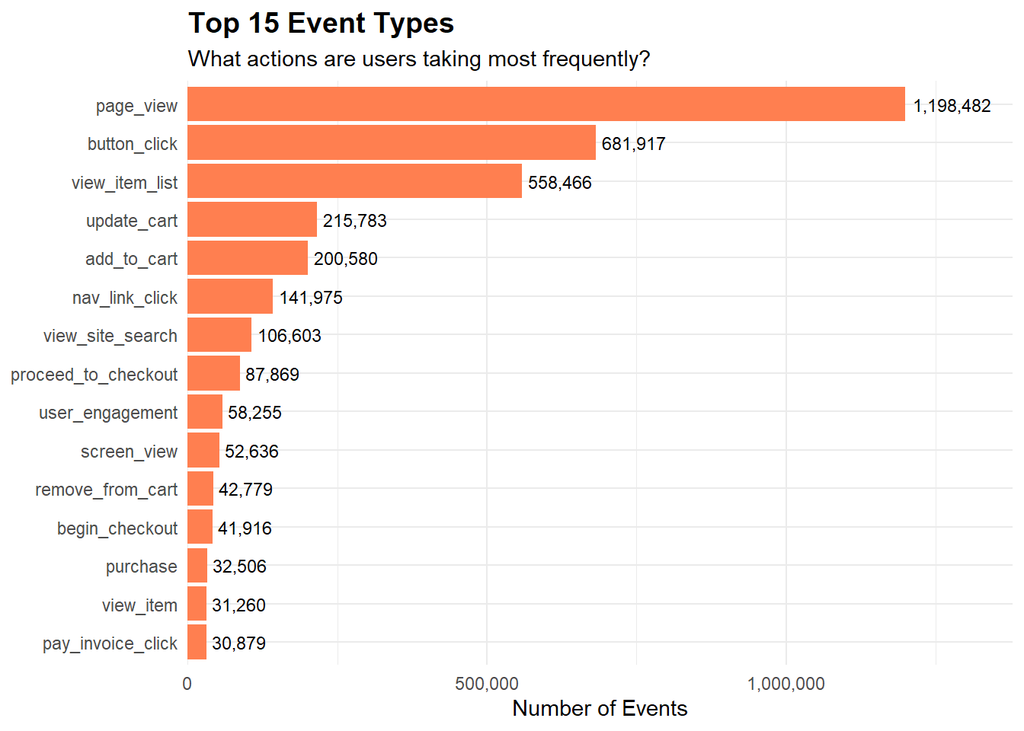

```r
# Most common events
event_summary <- google_analytics |>
  count(event_name, sort = TRUE) |>
  mutate(pct = n / sum(n) * 100)

# Top 15 events
ggplot(event_summary |> head(15),
       aes(x = reorder(event_name, n), y = n)) +
  geom_col(fill = "coral") +
  geom_text(aes(label = comma(n)), hjust = -0.1, size = 3) +
  coord_flip() +
  scale_y_continuous(labels = comma, expand = expansion(mult = c(0, 0.15))) +
  labs(title = "Top 15 Event Types",
       subtitle = "What actions are users taking most frequently?",
       x = NULL, y = "Number of Events") +
  theme_minimal() +
  theme(plot.title = element_text(face = "bold", size = 14))
```

## 4.2 Summary Stats for event types

**🖱️👆 Click to Show Code**

```r
# Create the summary stats table
summary_stats <- tibble(
  Metric = c(
    "Total Events",
    "Unique Customers",
    "Date Range",
    "Avg Events per Customer",
    "Total Purchases",
    "Desktop %",
    "Mobile %",
    "Most Common Event"
  ),
  Value = c(
    comma(nrow(google_analytics)),
    comma(n_distinct(google_analytics$customer_id)),
    paste(min(google_analytics$event_date), "to", max(google_analytics$event_date)),
    round(nrow(google_analytics) / n_distinct(google_analytics$customer_id), 1),
    comma(sum(google_analytics$event_name == "purchase")),
    paste0(round(sum(google_analytics$device_category == "desktop") / nrow(google_analytics) * 100, 1), "%"),
    paste0(round(sum(google_analytics$device_category == "mobile") / nrow(google_analytics) * 100, 1), "%"),
    event_summary$event_name[1]
  )
)

# Create the table with the kable package
summary_stats |>
  kable(format = "html", col.names = c("Metric", "Value"), escape = FALSE) |>
  kable_styling(bootstrap_options = c("striped", "hover", "condensed", "responsive"),
                full_width = FALSE,
                position = "left") |>
  column_spec(1, bold = TRUE, width = "30%") |>
  column_spec(2, width = "70%")
```

| Metric | Value |
| --- | --- |
| Total Events | 3,704,088 |
| Unique Customers | 6,334 |
| Date Range | 2024-05-31 to 2025-05-25 |
| Avg Events per Customer | 584.8 |
| Total Purchases | 32,506 |
| Desktop % | 82.4% |
| Mobile % | 16.6% |
| Most Common Event | page_view |

## 4.3 Event_Time Analysis

- When were users most active on the website?
- What time and day of the week was the most popular?

**🖱️👆 Click to Show Code**

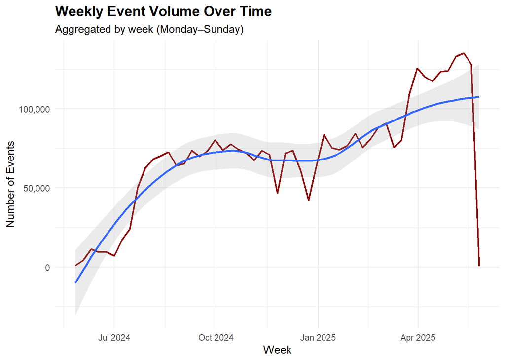

```r
# Weekly event volume
weekly_events <- google_analytics |>
  mutate(week = floor_date(event_ts_local, unit = "week", week_start = 1)) |>
  count(week) |>
  arrange(week)

# Plot the weekly volume
ggplot(weekly_events, aes(x = week, y = n)) +
  geom_line(color = "darkred", size = 0.8) +
  geom_smooth(method = "loess", se = TRUE, alpha = 0.2) +
  scale_y_continuous(labels = comma) +
  labs(title = "Weekly Event Volume Over Time",
       subtitle = "Aggregated by week (Monday–Sunday)",
       x = "Week", y = "Number of Events") +
  theme_minimal() +
  theme(plot.title = element_text(face = "bold", size = 14))
```

**🖱️👆 Click to Show Code**

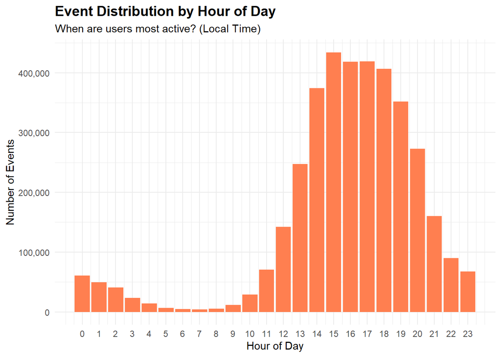

```r
# Hour of day analysis
hourly_pattern <- google_analytics |>
  mutate(hour = hour(event_ts_local),
         day_of_week = wday(event_ts_local)) |>
  count(hour)

# plot the hour of day analysis in a histogram
ggplot(hourly_pattern, aes(x = hour, y = n)) +
  geom_col(fill = "coral") +
  scale_x_continuous(breaks = 0:23) +
  scale_y_continuous(labels = comma) +
  labs(title = "Event Distribution by Hour of Day",
       subtitle = "When are users most active? (Local Time)",
       x = "Hour of Day", y = "Number of Events") +
  theme_minimal() +
  theme(plot.title = element_text(face = "bold", size = 14))
```

**🖱️👆 Click to Show Code**

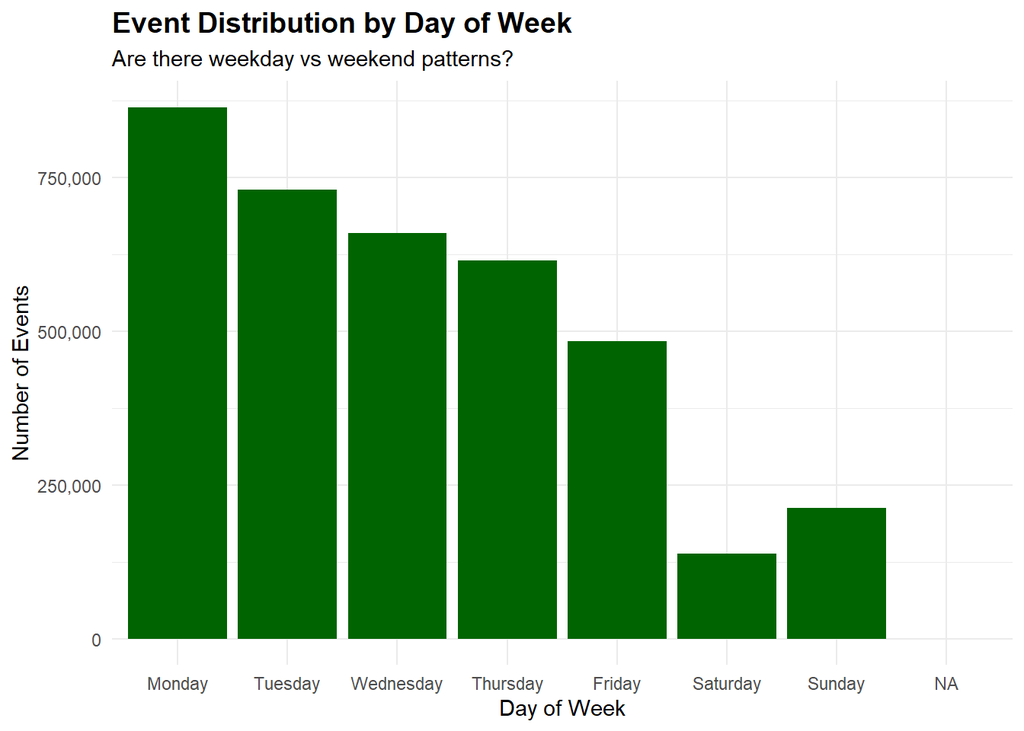

```r
# Day of week pattern
dow_pattern <- google_analytics |>
  mutate(day_of_week = factor(
    c("Sunday","Monday","Tuesday","Wednesday","Thursday","Friday","Saturday")[wday(event_ts_local)],
    levels = c("Monday","Tuesday","Wednesday","Thursday","Friday","Saturday","Sunday")
  )) |>
  count(day_of_week)

# Visualize this to see what day of the week trends look like
ggplot(dow_pattern, aes(x = day_of_week, y = n)) +
  geom_col(fill = "darkgreen") +
  scale_y_continuous(labels = comma) +
  labs(title = "Event Distribution by Day of Week",
       subtitle = "Are there weekday vs weekend patterns?",
       x = "Day of Week", y = "Number of Events") +
  theme_minimal() +
  theme(plot.title = element_text(face = "bold", size = 14))
```

## 4.4 Purchase Event Analysis

- These graphs are similar to the last section but now we ask the question, how did these trends play out for purchase events?
- Purchase events are a cornerstone of this project and we thought it would be interesting to observe them for these same graph.

**🖱️👆 Click to Show Code**

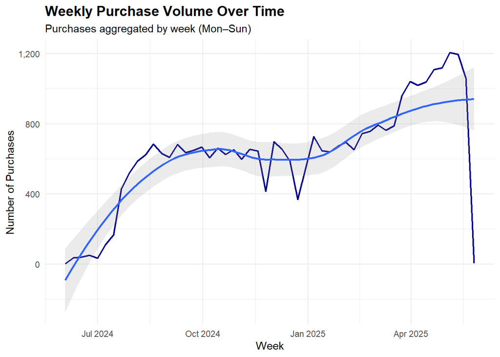

```r
# Weekly purchase event volume
weekly_purchases <- google_analytics |>
  filter(event_name == "purchase") |>
  mutate(week = floor_date(event_ts_local, unit = "week", week_start = 1)) |>
  count(week) |>
  arrange(week)

ggplot(weekly_purchases, aes(x = week, y = n)) +
  geom_line(color = "darkblue", size = 0.8) +
  geom_smooth(method = "loess", se = TRUE, alpha = 0.2) +
  scale_y_continuous(labels = comma) +
  labs(title = "Weekly Purchase Volume Over Time",
       subtitle = "Purchases aggregated by week (Mon–Sun)",
       x = "Week", y = "Number of Purchases") +
  theme_minimal() +
  theme(plot.title = element_text(face = "bold", size = 14))
```

**🖱️👆 Click to Show Code**

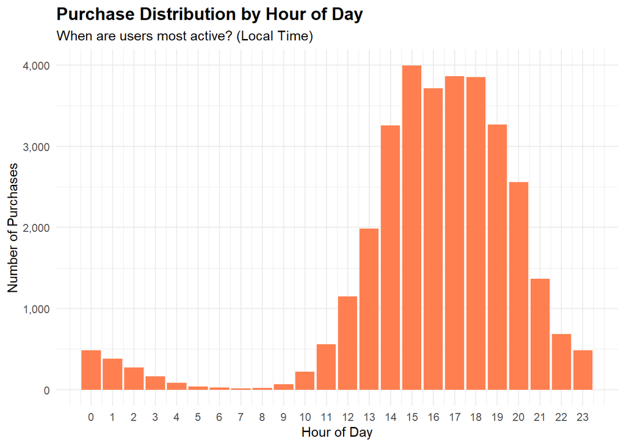

```r
# Hour of day analysis (purchase version)
hourly_pattern <- google_analytics |>
  filter(event_name == "purchase") |>
  mutate(hour = hour(event_ts_local),
         day_of_week = wday(event_ts_local)) |>
  count(hour)

ggplot(hourly_pattern, aes(x = hour, y = n)) +
  geom_col(fill = "coral") +
  scale_x_continuous(breaks = 0:23) +
  scale_y_continuous(labels = comma) +
  labs(title = "Purchase Distribution by Hour of Day",
       subtitle = "When are users most active? (Local Time)",
       x = "Hour of Day", y = "Number of Purchases") +
  theme_minimal() +
  theme(plot.title = element_text(face = "bold", size = 14))
```

**🖱️👆 Click to Show Code**

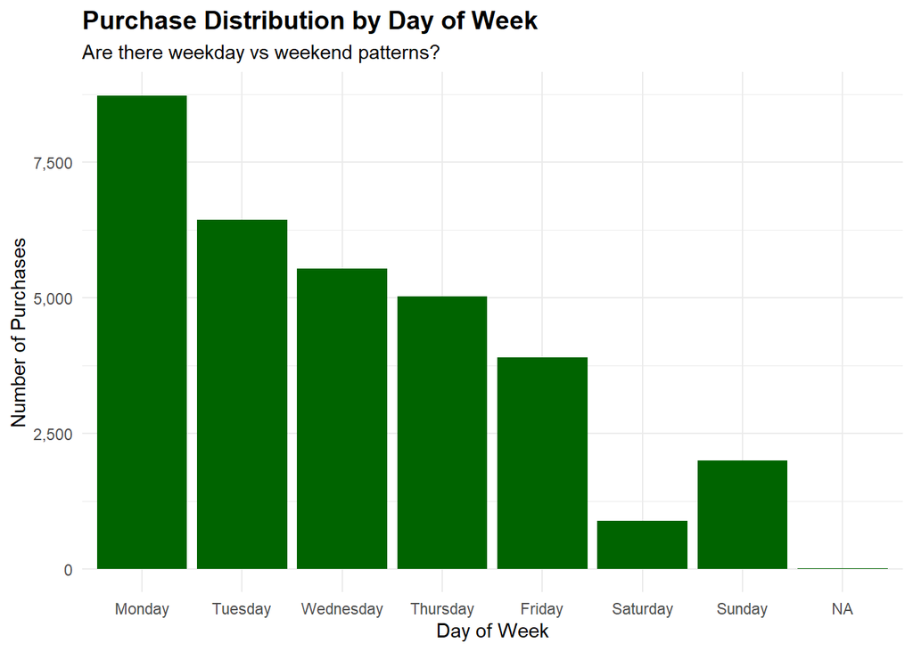

```r
# Day of week pattern (purchase version)
dow_pattern <- google_analytics |>
  filter(event_name == "purchase") |>
  mutate(day_of_week = factor(
    c("Sunday","Monday","Tuesday","Wednesday","Thursday","Friday","Saturday")[wday(event_ts_local)],
    levels = c("Monday","Tuesday","Wednesday","Thursday","Friday","Saturday","Sunday")
  )) |>
  count(day_of_week)

ggplot(dow_pattern, aes(x = day_of_week, y = n)) +
  geom_col(fill = "darkgreen") +
  scale_y_continuous(labels = comma) +
  labs(title = "Purchase Distribution by Day of Week",
       subtitle = "Are there weekday vs weekend patterns?",
       x = "Day of Week", y = "Number of Purchases") +
  theme_minimal() +
  theme(plot.title = element_text(face = "bold", size = 14))
```

**🖱️👆 Click to Show Code**

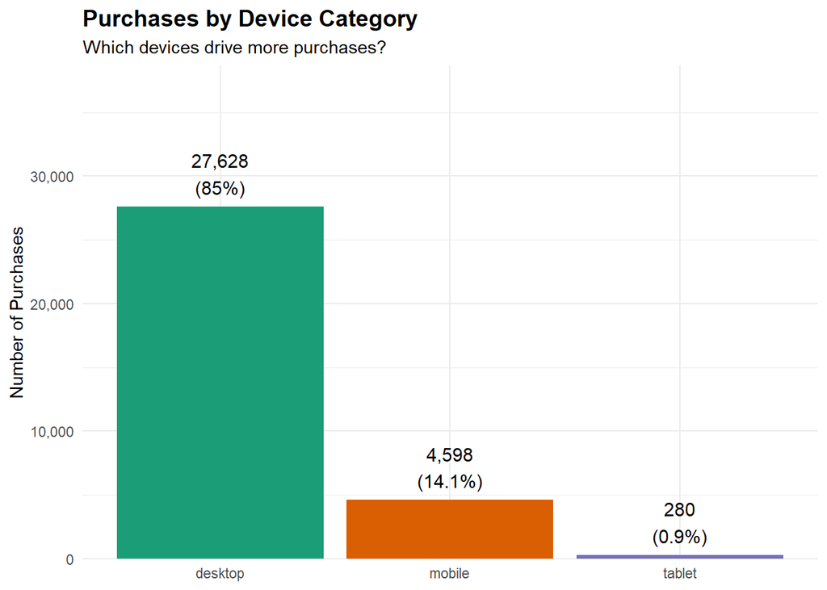

```r
# Device category for purchases
purchase_by_device <- google_analytics |>
  filter(event_name == "purchase") |>
  count(device_category) |>
  mutate(pct = n / sum(n) * 100)

ggplot(purchase_by_device, aes(x = reorder(device_category, -n), y = n, fill = device_category)) +
  geom_col(show.legend = FALSE) +
  geom_text(aes(label = paste0(comma(n), "\n(", round(pct, 1), "%)")),
            vjust = -0.3, size = 4) +
  scale_y_continuous(labels = comma, expand = expansion(mult = c(0, 0.4))) +
  scale_fill_brewer(palette = "Dark2") +
  labs(title = "Purchases by Device Category",
       subtitle = "Which devices drive more purchases?",
       x = NULL, y = "Number of Purchases") +
  theme_minimal() +
  theme(plot.title = element_text(face = "bold", size = 14))
```

- Purchase volume has increased steadily throughout the year of data with purchases peaking in May 2025
- Events occur mainly in the period of 12pm to 8pm local time for each customer.
- Most Events (purchase and all others) take place on monday and event volume decreases throughout the week.
- Most purchase events occur on the desktop.

## 4.5 Incomplete Purchase Analysis

**Note**

This section is a bit more experimental, it was completed before we figured out the true order window problem but we thought it could still be interesting to leave it here.

**🖱️👆 Click to Show Code**

```r
# Define a "session" as activity within X hours
SESSION_TIMEOUT_HOURS <- 10
 # I set this to 10 hours for a session to give ample time to complete a transaction for customers
 # This is where things won't exatly line up with our defined order_windows later on because this solution has the potential to missrepresent order windows based on cutoff_times in the visit_plan table.


# Create sessions based on time gaps
create_sessions <- function(data) {
  data |>
    arrange(customer_id, event_timestamp) |>
    group_by(customer_id) |>
    mutate(
      time_since_last = as.numeric(difftime(event_timestamp, lag(event_timestamp), units = "hours")),
      new_session = is.na(time_since_last) | time_since_last > SESSION_TIMEOUT_HOURS,
      session_id = cumsum(new_session)
    ) |>
    ungroup() |>
    mutate(session_key = paste(customer_id, session_id, sep = "_"))
}

# Apply session creation
google_analytics_sessions <- create_sessions(google_analytics)

cat("Session timeout set to:", SESSION_TIMEOUT_HOURS, "hours\n")
```

```
Session timeout set to: 10 hours
```

**🖱️👆 Click to Show Code**

```r
cat("Total sessions created:", n_distinct(google_analytics_sessions$session_key), "\n\n")
```

```
Total sessions created: 78813
```

**🖱️👆 Click to Show Code**

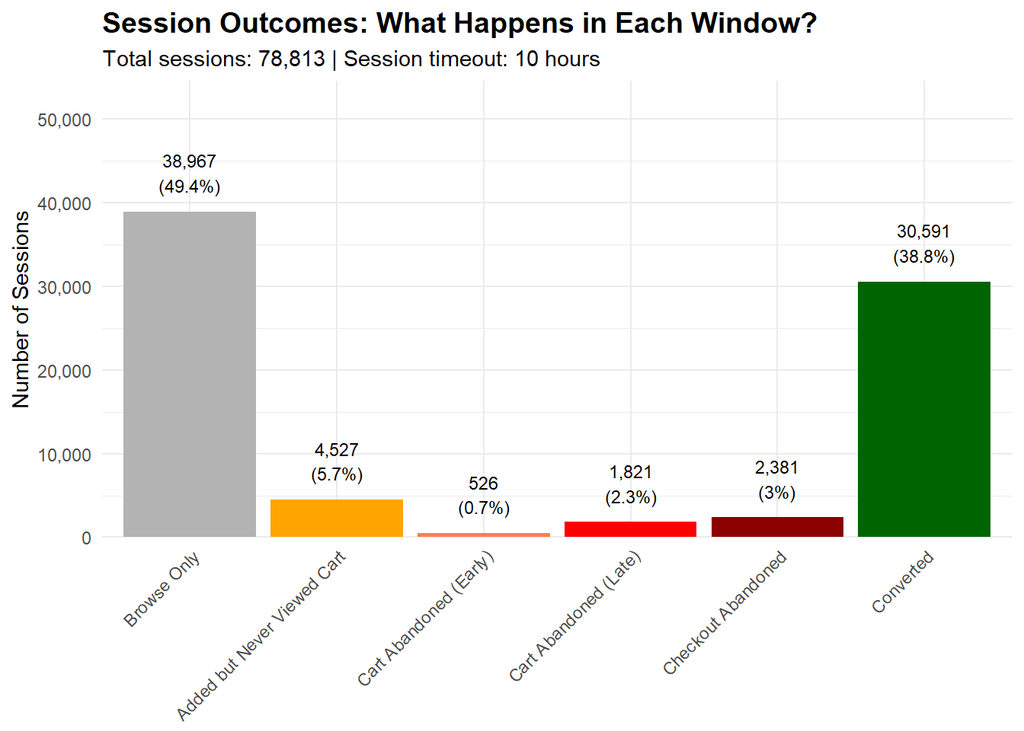

```r
# SESSION-LEVEL CONVERSION STEPS

# Classify each session by what happened
session_summary <- google_analytics_sessions |>
  group_by(session_key, customer_id, session_id) |>
  summarise(
    session_start = min(event_timestamp),
    session_end = max(event_timestamp),
    session_duration_mins = as.numeric(difftime(max(event_timestamp), min(event_timestamp), units = "mins")),
    num_events = n(),

    # Key actions in session
    had_add_to_cart = any(event_name == "add_to_cart"),
    had_view_cart = any(event_name == "view_cart"),
    had_proceed_to_checkout = any(event_name == "proceed_to_checkout"),
    had_begin_checkout = any(event_name == "begin_checkout"),
    had_add_payment = any(event_name == "add_payment_info"),
    had_purchase = any(event_name == "purchase"),
    had_remove_from_cart = any(event_name == "remove_from_cart"),

    # Counts
    add_to_cart_count = sum(event_name == "add_to_cart"),
    remove_from_cart_count = sum(event_name == "remove_from_cart"),
    update_cart_count = sum(event_name == "update_cart"),

    # Device and errors
    device = first(device_category),
    had_error = any(grepl("Failed|Error|failed", event_name)),

    .groups = "drop"
  ) |>
  mutate(
    # Session outcome classification
    session_type = case_when(
      had_purchase ~ "Converted",
      had_begin_checkout ~ "Checkout Abandoned",
      had_proceed_to_checkout ~ "Cart Abandoned (Late)",
      had_view_cart ~ "Cart Abandoned (Early)",
      had_add_to_cart ~ "Added but Never Viewed Cart",
      TRUE ~ "Browse Only"
    ),
    session_type = factor(session_type, levels = c(
      "Browse Only", "Added but Never Viewed Cart",
      "Cart Abandoned (Early)", "Cart Abandoned (Late)",
      "Checkout Abandoned", "Converted"
    ))
  )

# Session outcome distribution
session_outcomes <- session_summary |>
  count(session_type) |>
  mutate(pct = n / sum(n) * 100)

ggplot(session_outcomes, aes(x = session_type, y = n, fill = session_type)) +
  geom_col(show.legend = FALSE) +
  geom_text(aes(label = paste0(comma(n), "\n(", round(pct, 1), "%)")),
            vjust = -0.5, size = 3) +
  scale_y_continuous(labels = comma, expand = expansion(mult = c(0, 0.4))) +
  scale_fill_manual(values = c("grey70", "orange", "coral", "red", "darkred", "darkgreen")) +
  labs(title = "Session Outcomes: What Happens in Each Window?",
       subtitle = paste0("Total sessions: ", comma(nrow(session_summary)),
                        " | Session timeout: ", SESSION_TIMEOUT_HOURS, " hours"),
       x = NULL, y = "Number of Sessions") +
  theme_minimal() +
  theme(plot.title = element_text(face = "bold", size = 14),
        axis.text.x = element_text(angle = 45, hjust = 1))
```

- This showed that we had 78,813 total “sessions” in the dataset.
- ~ 50% of these were sessions that never involved a customer adding an item to their cart
- ~ 40% of these ended in full conversion with a purchase by the customer
- It seems that many of the in-between events were not necessarily required to reach the full purchase.

## 4.6 Device Analysis

- Which devices were customers using to access the platform?
- Are there any issues with the current distribution of platform usage across devices?

**🖱️👆 Click to Show Code**

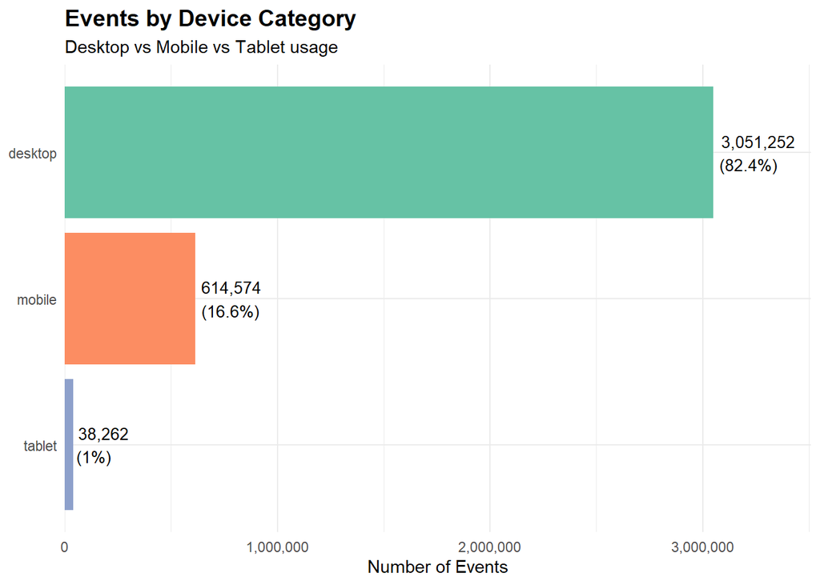

```r
# Device category breakdown
device_summary <- google_analytics |>
  count(device_category, sort = TRUE) |>
  mutate(pct = n / sum(n) * 100)

ggplot(device_summary, aes(x = reorder(device_category, n), y = n, fill = device_category)) +
  geom_col(show.legend = FALSE) +
  geom_text(aes(label = paste0(comma(n), "\n(", round(pct, 1), "%)")),
            hjust = -0.1, size = 3.5) +
  coord_flip() +
  scale_y_continuous(labels = comma, expand = expansion(mult = c(0, 0.15))) +
  scale_fill_brewer(palette = "Set2") +
  labs(title = "Events by Device Category",
       subtitle = "Desktop vs Mobile vs Tablet usage",
       x = NULL, y = "Number of Events") +
  theme_minimal() +
  theme(plot.title = element_text(face = "bold", size = 14))
```

**🖱️👆 Click to Show Code**

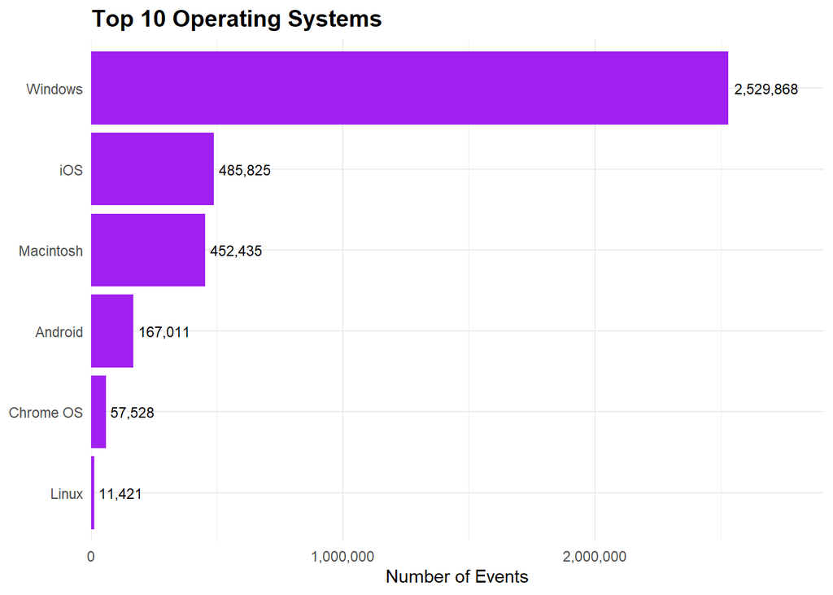

```r
# Operating system distribution
os_summary <- google_analytics |>
  count(device_operating_system, sort = TRUE) |>
  head(10)

ggplot(os_summary, aes(x = reorder(device_operating_system, n), y = n)) +
  geom_col(fill = "purple") +
  geom_text(aes(label = comma(n)), hjust = -0.1, size = 3) +
  coord_flip() +
  scale_y_continuous(labels = comma, expand = expansion(mult = c(0, 0.15))) +
  labs(title = "Top 10 Operating Systems",
       x = NULL, y = "Number of Events") +
  theme_minimal() +
  theme(plot.title = element_text(face = "bold", size = 14))
```

**🖱️👆 Click to Show Code**

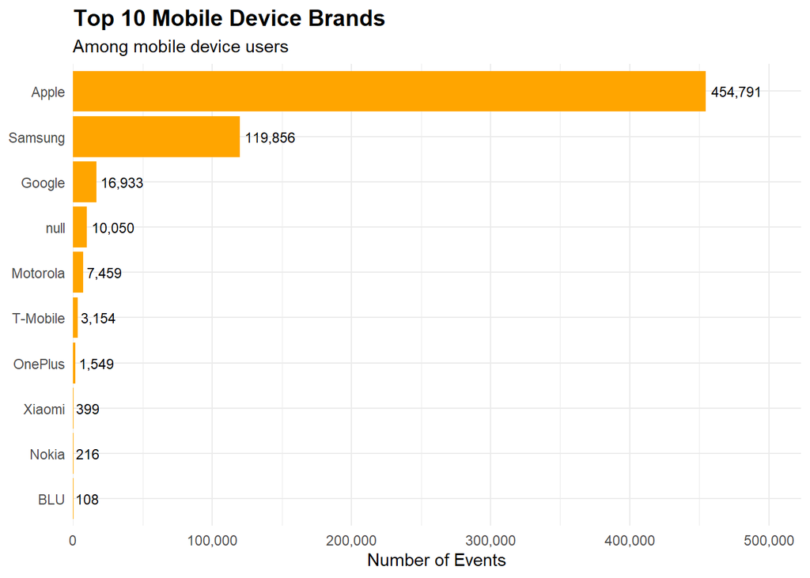

```r
# Mobile brand analysis (for mobile devices only)
mobile_brands <- google_analytics |>
  filter(device_category == "mobile") |>
  count(device_mobile_brand_name, sort = TRUE) |>
  head(10)

ggplot(mobile_brands, aes(x = reorder(device_mobile_brand_name, n), y = n)) +
  geom_col(fill = "orange") +
  geom_text(aes(label = comma(n)), hjust = -0.1, size = 3) +
  coord_flip() +
  scale_y_continuous(labels = comma, expand = expansion(mult = c(0, 0.15))) +
  labs(title = "Top 10 Mobile Device Brands",
       subtitle = "Among mobile device users",
       x = NULL, y = "Number of Events") +
  theme_minimal() +
  theme(plot.title = element_text(face = "bold", size = 14))
```

- The majority of users access the mycoke 360 platform from their desktop but we do have a decent subset of users who use the platform on mobile, **16.6%**.
- Most users access the site using Windows with Apple’s IOS and Mac OS following in 2nd and 3rd most popular.
- Among mobile devices Apple is the most common with Samsung and Google next in line.

## 4.7 Customer Behavior

- How often do customers use the platform?

**🖱️👆 Click to Show Code**

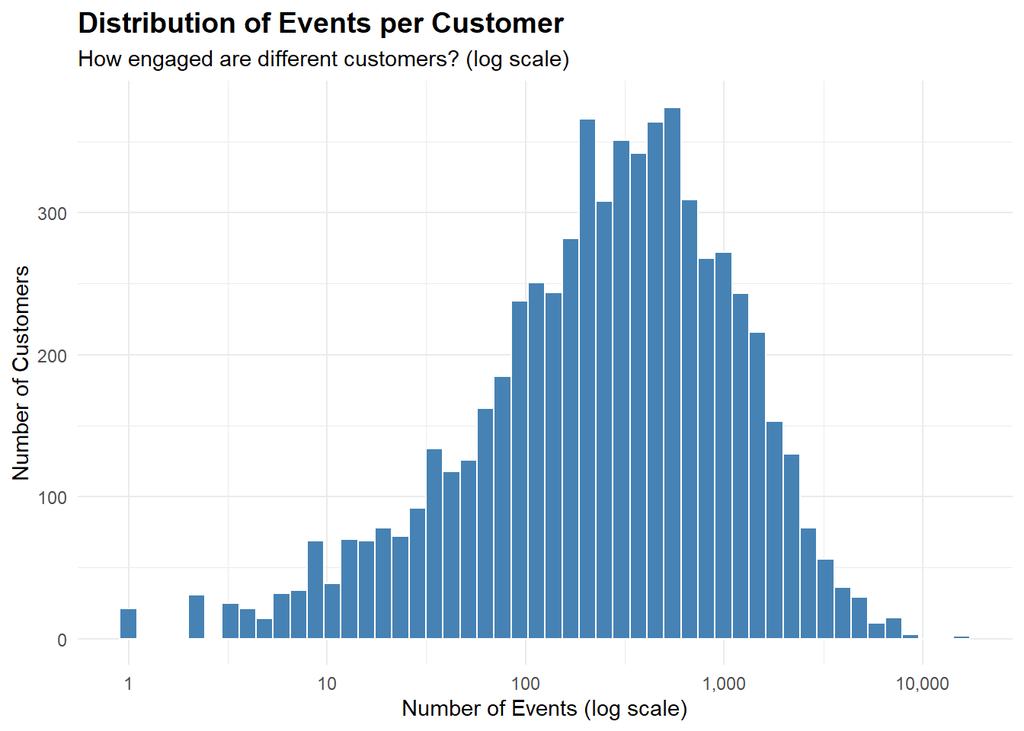

```r
# Events per customer distribution
events_per_customer <- google_analytics |>
  count(customer_id, name = "num_events") |>
  mutate(engagement_level = case_when(
    num_events <= 50 ~ "Light user",
    num_events <= 500 ~ "Moderate user",
    num_events <= 1000 ~ "Active user",
    TRUE ~ "Power user"
  ))

# Events per customer log scale histogram
ggplot(events_per_customer, aes(x = num_events)) +
  geom_histogram(bins = 50, fill = "steelblue", color = "white") +
  scale_x_log10(labels = comma) +
  scale_y_continuous(labels = comma) +
  labs(title = "Distribution of Events per Customer",
       subtitle = "How engaged are different customers? (log scale)",
       x = "Number of Events (log scale)", y = "Number of Customers") +
  theme_minimal() +
  theme(plot.title = element_text(face = "bold", size = 14))
```

**🖱️👆 Click to Show Code**

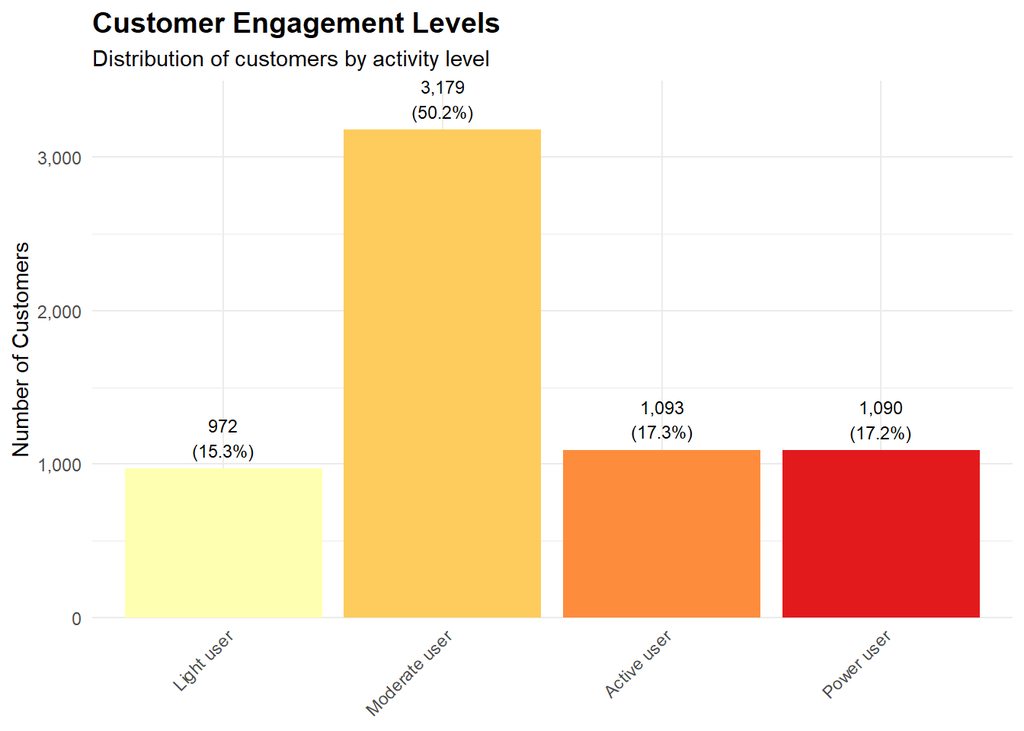

```r
# Engagement level summary
engagement_summary <- events_per_customer |>
  count(engagement_level) |>
  mutate(pct = n / sum(n) * 100,
         engagement_level = factor(engagement_level,
                                   levels = c("One-time visitor", "Light user",
                                             "Moderate user", "Active user", "Power user")))

# Enngagement level plot
ggplot(engagement_summary, aes(x = engagement_level, y = n, fill = engagement_level)) +
  geom_col(show.legend = FALSE) +
  geom_text(aes(label = paste0(comma(n), "\n(", round(pct, 1), "%)")),
            vjust = -0.3, size = 3) +
  scale_y_continuous(labels = comma, expand = expansion(mult = c(0, 0.1))) +
  scale_fill_brewer(palette = "YlOrRd") +
  labs(title = "Customer Engagement Levels",
       subtitle = "Distribution of customers by activity level",
       x = NULL, y = "Number of Customers") +
  theme_minimal() +
  theme(plot.title = element_text(face = "bold", size = 14),
        axis.text.x = element_text(angle = 45, hjust = 1))
```

## 4.8 Page Analysis

- Which pages were the most frequently visited on the site?

**🖱️👆 Click to Show Code**

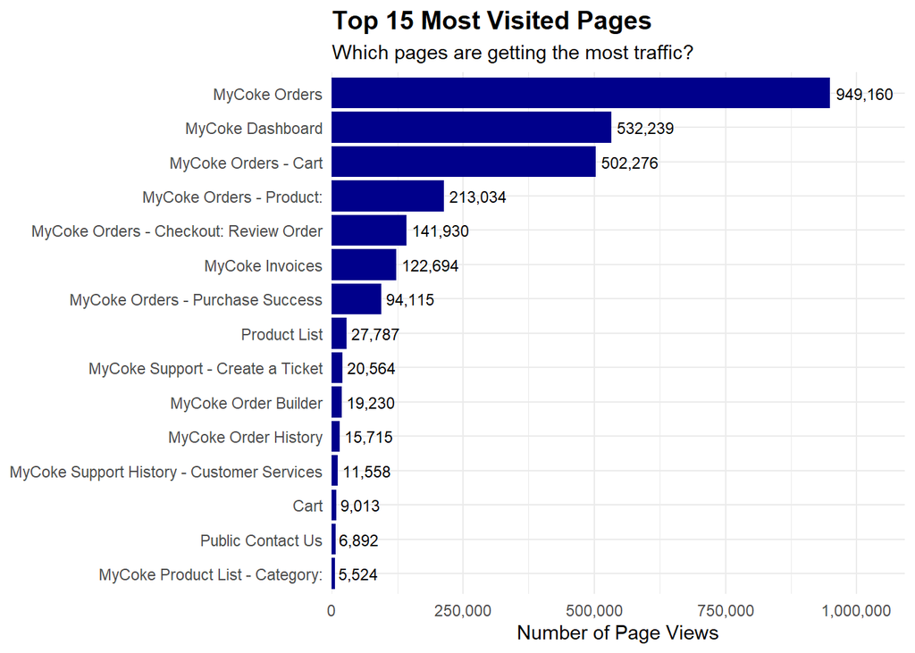

```r
# Most visited pages (excluding null)
page_summary <- google_analytics |>
  filter(event_page_name != "null", !is.na(event_page_name)) |>
  count(event_page_name, sort = TRUE) |>
  head(15)

ggplot(page_summary, aes(x = reorder(event_page_name, n), y = n)) +
  geom_col(fill = "darkblue") +
  geom_text(aes(label = comma(n)), hjust = -0.1, size = 3) +
  coord_flip() +
  scale_y_continuous(labels = comma, expand = expansion(mult = c(0, 0.15))) +
  labs(title = "Top 15 Most Visited Pages",
       subtitle = "Which pages are getting the most traffic?",
       x = NULL, y = "Number of Page Views") +
  theme_minimal() +
  theme(plot.title = element_text(face = "bold", size = 14))
```

- The MyCoke Orders Page had the most traffic by far.
- This shows that many customers think about and modify their orders many times before actually reaching a purchase event.
- Purchase events accounted for **94,115** total events.

# 5 📦 Orders Table EDA

**🖱️👆 Click to Show Code**

```r
# quick view
glimpse(orders)
```

```
Rows: 1,662,157
Columns: 7
$ customer_id      <int> 600265510, 600584506, 600686120, 501087671, 501680332…
$ created_date_est <IDate> 2025-01-10, 2024-11-22, 2024-06-04, 2024-12-03, 202…
$ created_date_utc <dttm> 2025-01-10 22:40:25, 2024-11-22 17:34:30, 2024-06-05…
$ material_id      <int> 152965, 156127, 103886, 134926, 152196, 144090, 10196…
$ order_quantity   <dbl> 1, 1, 1, 2, 1, 1, 1, 1, 1, 1, 2, 1, 2, 1, 2, 3, 1, 1,…
$ order_type       <chr> "CALL CENTER", "SALES REP", "SALES REP", "SALES REP",…
$ plant_id         <chr> "G267", "G221", "G291", "G163", "G221", "G293", "G221…
```

## 5.1 Order Volume

- Which months had the most orders?

**🖱️👆 Click to Show Code**

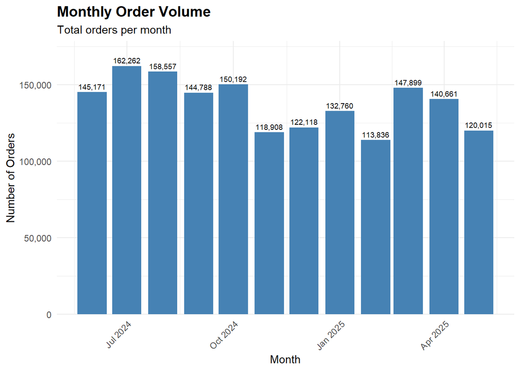

```r
# Monthly order volume
monthly_orders <- orders |>
  filter(created_date_est > as.Date("2024-05-31")) |> # May has hardly anything and doesn't add to the viz
  mutate(month = floor_date(created_date_est, "month")) |>
  count(month, name = "num_orders")

ggplot(monthly_orders, aes(x = month, y = num_orders)) +
  geom_col(fill = "steelblue") +
  geom_text(aes(label = comma(num_orders)), vjust = -0.5, size = 2.5) +
  scale_y_continuous(labels = comma, expand = expansion(mult = c(0, 0.1))) +
  labs(title = "Monthly Order Volume",
       subtitle = "Total orders per month",
       x = "Month", y = "Number of Orders") +
  theme_minimal() +
  theme(plot.title = element_text(face = "bold", size = 14),
        axis.text.x = element_text(angle = 45, hjust = 1))
```

- This looks pretty even throughout the year with a little dip in November and December

## 5.2 Order Type Analysis

- How are customers placing orders?
- Are we seeing customers use the mycoke360 platform more often?

**🖱️👆 Click to Show Code**

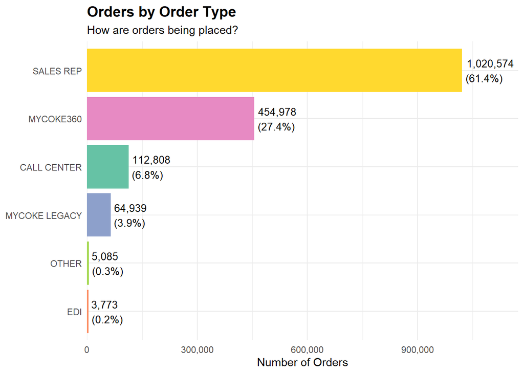

```r
# Order type distribution
order_type_summary <- orders |>
  count(order_type, sort = TRUE) |>
  mutate(pct = n / sum(n) * 100)

ggplot(order_type_summary, aes(x = reorder(order_type, n), y = n, fill = order_type)) +
  geom_col(show.legend = FALSE) +
  geom_text(aes(label = paste0(comma(n), "\n(", round(pct, 1), "%)")),
            hjust = -0.1, size = 3.5) +
  coord_flip() +
  scale_y_continuous(labels = comma, expand = expansion(mult = c(0, 0.15))) +
  scale_fill_brewer(palette = "Set2") +
  labs(title = "Orders by Order Type",
       subtitle = "How are orders being placed?",
       x = NULL, y = "Number of Orders") +
  theme_minimal() +
  theme(plot.title = element_text(face = "bold", size = 14))
```

**🖱️👆 Click to Show Code**

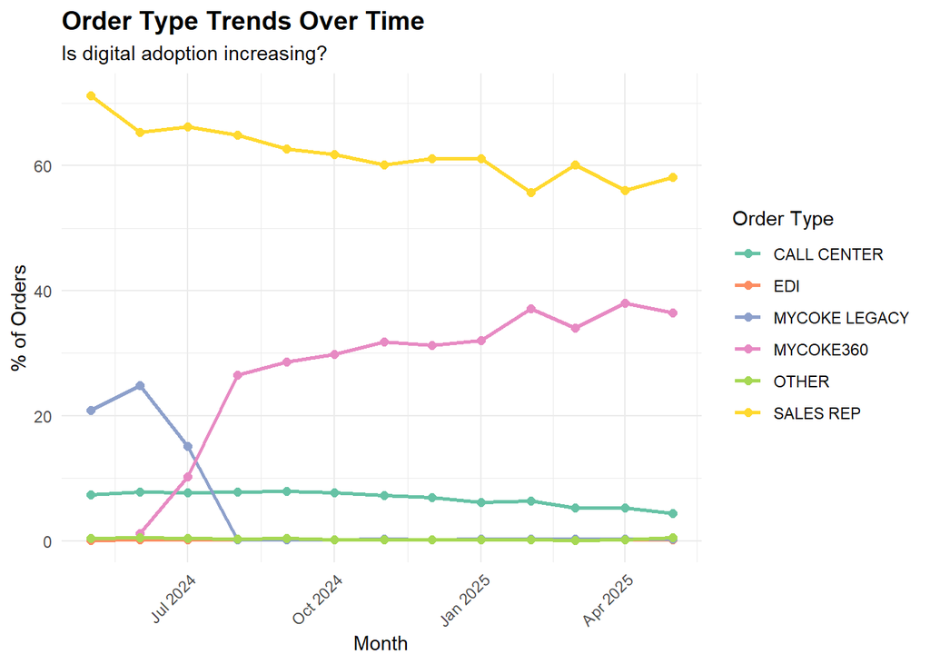

```r
# Order type trend over time
order_type_trend <- orders |>
  mutate(month = floor_date(created_date_est, "month")) |>
  count(month, order_type) |>
  group_by(month) |>
  mutate(pct = n / sum(n) * 100) |>
  ungroup()

ggplot(order_type_trend, aes(x = month, y = pct, color = order_type, group = order_type)) +
  geom_line(size = 1) +
  geom_point(size = 2) +
  scale_y_continuous(labels = comma) +
  scale_color_brewer(palette = "Set2") +
  labs(title = "Order Type Trends Over Time",
       subtitle = "Is digital adoption increasing?",
       x = "Month", y = "% of Orders", color = "Order Type") +
  theme_minimal() +
  theme(plot.title = element_text(face = "bold", size = 14),
        axis.text.x = element_text(angle = 45, hjust = 1))
```

- These show that while Sales Reps are still taking most of the order share, the **MyCoke360 platform has increased in usage** as the year has gone on.

## 5.3 Order Quantity Table

**🖱️👆 Click to Show Code**

```r
# Create the table
quantity_summary <- orders |>
  summarise(
    `Mean Order Quantity` = round(mean(order_quantity, na.rm = TRUE), 2),
    `Median Order Quantity` = median(order_quantity, na.rm = TRUE),
    `Max Order Quantity` = max(order_quantity, na.rm = TRUE),
    `Total Units Ordered` = sum(order_quantity, na.rm = TRUE)
  ) |>
  pivot_longer(everything(), names_to = "Metric", values_to = "Value") |>
  mutate(Value = ifelse(Metric %in% c("Max Order Quantity", "Total Units Ordered"),
                        comma(Value), as.character(Value)))

# Desplay in a nice Kable HTML table
kbl(
  quantity_summary,
  format = "html",
  caption = "Order Quantity Summary",
  align = c("l", "r")
) |>
  kable_styling(
    bootstrap_options = c("striped", "hover", "condensed", "responsive"),
    full_width = FALSE,
    position = "center"
  )
```

Order Quantity Summary

| Metric | Value |
| --- | --- |
| Mean Order Quantity | 2.81 |
| Median Order Quantity | 1 |
| Max Order Quantity | 2,000.0 |
| Total Units Ordered | 4,671,943.0 |

## 5.4 Product (Material) Analysis

- Which products were most popular?

**🖱️👆 Click to Show Code**

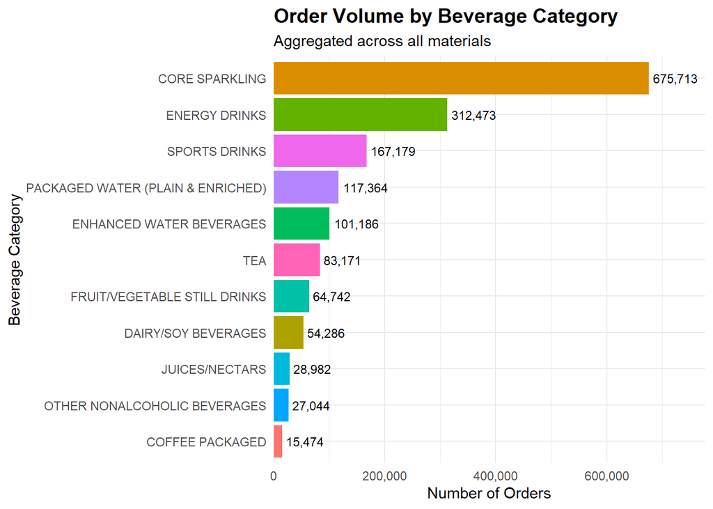

```r
# Join the materials table so we can learn more about specific product trends beyond ID
orders_material <- orders |>
  left_join(material, by = "material_id") |>
    filter(!is.na(bev_cat_desc), # Filter out the NA and "" categories
          bev_cat_desc != "")

# ---- Category-level summary ----
category_summary <- orders_material |>
  group_by(bev_cat_desc) |>
  summarise(
    total_orders = n(),
    total_quantity = sum(order_quantity, na.rm = TRUE),
    unique_products = n_distinct(material_id),
    unique_customers = n_distinct(customer_id),
    .groups = "drop"
  ) |>
  arrange(desc(total_orders))


# ---- Plot: Category-level volume ----
ggplot(category_summary, aes(x = reorder(bev_cat_desc, total_orders), y = total_orders, fill = bev_cat_desc)) +
  geom_col(show.legend = FALSE) +
  geom_text(aes(label = comma(total_orders)), hjust = -0.1, size = 3) +
  coord_flip() +
  scale_y_continuous(labels = comma, expand = expansion(mult = c(0, 0.15))) +
  labs(
    title = "Order Volume by Beverage Category",
    subtitle = "Aggregated across all materials",
    x = "Beverage Category",
    y = "Number of Orders"
  ) +
  theme_minimal() +
  theme(plot.title = element_text(face = "bold", size = 14))
```

**🖱️👆 Click to Show Code**

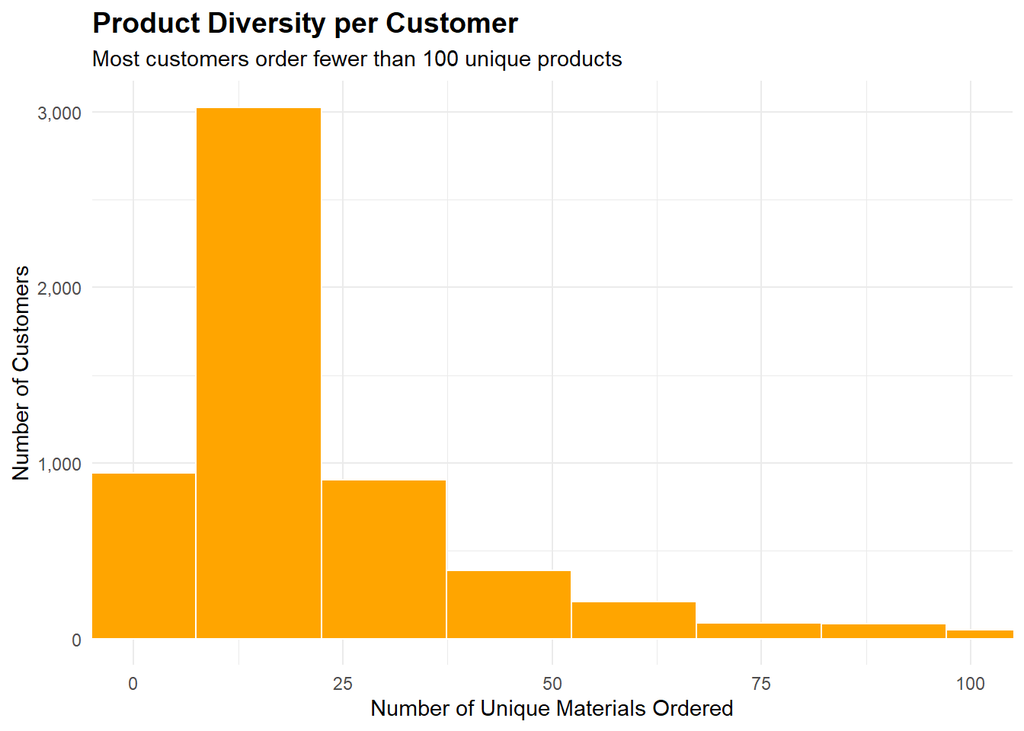

```r
# Product diversity
product_diversity <- orders_material |>
  group_by(customer_id) |>
  summarise(unique_products = n_distinct(material_id), .groups = "drop")

# Filter to less than 100
ggplot(product_diversity, aes(x = unique_products)) +
  geom_histogram(bins = 30, fill = "orange", color = "white") +
  coord_cartesian(xlim = c(0, 100)) +  # I set this to 100 because most customers have less than that
  scale_y_continuous(labels = comma) +
  labs(
    title = "Product Diversity per Customer",
    subtitle = "Most customers order fewer than 100 unique products",
    x = "Number of Unique Materials Ordered",
    y = "Number of Customers"
  ) +
  theme_minimal() +
  theme(plot.title = element_text(face = "bold", size = 14))
```

- The most popular category is “Core Sparkling” this includes sodas which make up the majority of orders.
- Most customers purchase less than 100 different items across all orders, this tells us that the majority of the customers do not drastically modify the items they order throughout the year.

## 5.5 Top Products by Category Table

- Click the tab below to see the full table.

**🖱️👆 Click to Show Code**

```r
# Top products table

# Top 3 products per category
top_products_by_cat <- orders_material |>
  group_by(bev_cat_desc, material_id, trade_mark_desc, flavour_desc, pack_size_desc) |>
  summarise(
    num_orders = n(),
    total_quantity = sum(order_quantity, na.rm = TRUE),
    .groups = "drop"
  ) |>
  arrange(bev_cat_desc, desc(num_orders)) |>
  group_by(bev_cat_desc) |>  # per category
  slice_head(n = 3) |>
  ungroup() |>                # remove grouping before table
  mutate(Product = paste0(trade_mark_desc, " - ", flavour_desc, " (", pack_size_desc, ")")) |>
  select(Beverage_Category = bev_cat_desc, Product, `# Orders` = num_orders, `Total Quantity` = total_quantity)

# Create HTML table
top_products_by_cat |>
  kable(format = "html", escape = FALSE, align = "lccc") |>
  kable_styling(full_width = FALSE, bootstrap_options = c("striped", "hover", "condensed")) |>
  add_header_above(c(" " = 1, "Top Products per Beverage Category" = 3))
```

| Beverage_Category | Top Products per Beverage Category Product | Top Products per Beverage Category # Orders | Top Products per Beverage Category Total Quantity |
| --- | --- | --- | --- |
| COFFEE PACKAGED | Fizz Factory - Vanilla Chai Latte (13.7 OZ) | 5266 | 15324 |
| COFFEE PACKAGED | Fizz Factory - Cherry Vanilla (13.7 OZ) | 4900 | 11369 |
| COFFEE PACKAGED | Fizz Factory - Pineapple (13.7 OZ) | 3183 | 6756 |
| CORE SPARKLING | Oliver Originals - Vanilla Latte (20 OZ) | 34943 | 143930 |
| CORE SPARKLING | Oliver Originals - Vanilla Latte (5 GALLON) | 32433 | 49370 |
| CORE SPARKLING | Oliver Originals - Vanilla Latte (20 OZ) | 24974 | 77469 |
| DAIRY/SOY BEVERAGES | Fizz Factory - Coconut (14 OZ) | 8520 | 33034 |
| DAIRY/SOY BEVERAGES | Fizz Factory - Coconut (14 OZ) | 8289 | 30217 |
| DAIRY/SOY BEVERAGES | Fizz Factory - Orange Cream (14 OZ) | 6669 | 19857 |
| ENERGY DRINKS | Fizz Factory - Berry Blast (16 OZ) | 15868 | 83256 |
| ENERGY DRINKS | Fizz Factory - Matcha (16 OZ) | 13912 | 56267 |
| ENERGY DRINKS | Bobby's Bottles - Matcha (16 OZ) | 9696 | 26417 |
| ENHANCED WATER BEVERAGES | Pete's Popcorn - Maple (20 OZ) | 12140 | 38873 |
| ENHANCED WATER BEVERAGES | Pete's Popcorn - Cotton Candy (20 OZ) | 10215 | 23244 |
| ENHANCED WATER BEVERAGES | Pete's Popcorn - Espresso Bean (20 OZ) | 7544 | 12174 |
| FRUIT/VEGETABLE STILL DRINKS | Sam's - Orange (2.5 GALLON) | 13719 | 20541 |
| FRUIT/VEGETABLE STILL DRINKS | Sam's - Orange (20 OZ) | 7229 | 19408 |
| FRUIT/VEGETABLE STILL DRINKS | Fizz Factory - Cherry (10.1 OZ) | 5671 | 7914 |
| JUICES/NECTARS | Sam's - Caramel Macchiato (12 OZ) | 9725 | 20307 |
| JUICES/NECTARS | Sam's - Chocolate Fudge (12 OZ) | 8922 | 18711 |
| JUICES/NECTARS | Sam's - Raspberry Lime (12 OZ) | 3616 | 5810 |
| OTHER NONALCOHOLIC BEVERAGES | Fizz Factory - Tangerine (20 POUND) | 16364 | 31860 |
| OTHER NONALCOHOLIC BEVERAGES | Fizz Factory - Tangerine (5 GALLON) | 1406 | 5344 |
| OTHER NONALCOHOLIC BEVERAGES | Fizz Factory - Tangerine (23 OZ) | 1205 | 7155 |
| PACKAGED WATER (PLAIN & ENRICHED) | Blueberry Hill - Vanilla Raspberry (20 OZ) | 20475 | 183315 |
| PACKAGED WATER (PLAIN & ENRICHED) | Pete's Popcorn - Vanilla Raspberry (33.8 OZ) | 16471 | 68149 |
| PACKAGED WATER (PLAIN & ENRICHED) | Pete's Popcorn - Vanilla Raspberry (20 OZ) | 14769 | 78264 |
| SPORTS DRINKS | Billy's Lemonade - Mango (2.5 GALLON) | 9621 | 16928 |
| SPORTS DRINKS | Billy's Lemonade - Banana (28 OZ) | 9453 | 15107 |
| SPORTS DRINKS | Billy's Lemonade - Banana (20 OZ) | 8326 | 24535 |
| TEA | Fizz Factory - Ginger Snap (18.5 OZ) | 15230 | 41816 |
| TEA | Fizz Factory - Pumpkin Latte (23 OZ) | 9815 | 21069 |
| TEA | Fizz Factory - Yogurt (23 OZ) | 9745 | 23610 |

## 5.6 Plant/Fulfillment Analysis

- Which plants process the most orders?

**🖱️👆 Click to Show Code**

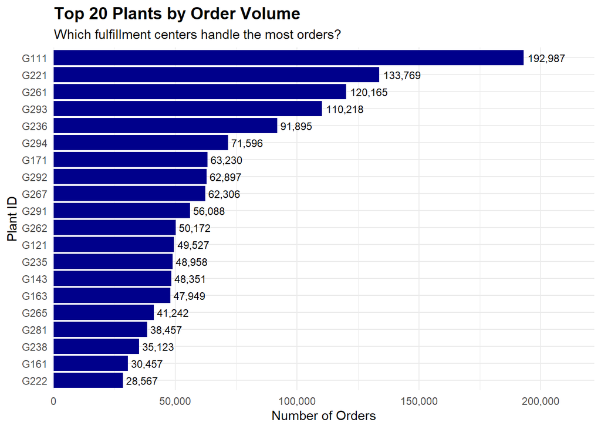

```r
# Orders by plant
plant_summary <- orders |>
  count(plant_id, sort = TRUE) |>
  head(20) |>
  mutate(pct = n / sum(n) * 100)

ggplot(plant_summary, aes(x = reorder(plant_id, n), y = n)) +
  geom_col(fill = "darkblue") +
  geom_text(aes(label = comma(n)), hjust = -0.1, size = 3) +
  coord_flip() +
  scale_y_continuous(labels = comma, expand = expansion(mult = c(0, 0.15))) +
  labs(title = "Top 20 Plants by Order Volume",
       subtitle = "Which fulfillment centers handle the most orders?",
       x = "Plant ID", y = "Number of Orders") +
  theme_minimal() +
  theme(plot.title = element_text(face = "bold", size = 14))
```

**🖱️👆 Click to Show Code**

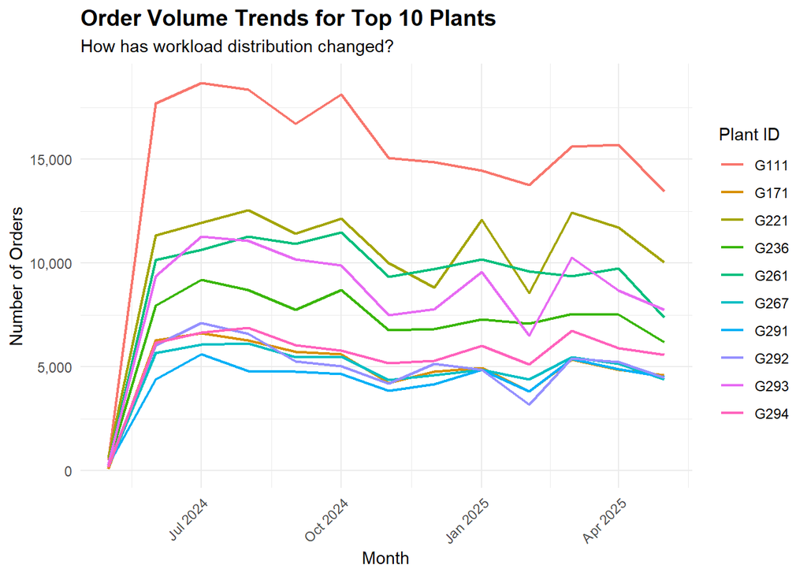

```r
# Plant workload over time
top_plants <- orders |> count(plant_id, sort = TRUE) |> head(10) |> pull(plant_id)

plant_trend <- orders |>
  filter(plant_id %in% top_plants) |>
  mutate(month = floor_date(created_date_est, "month")) |>
  count(month, plant_id)

ggplot(plant_trend, aes(x = month, y = n, color = plant_id, group = plant_id)) +
  geom_line(size = 0.8) +
  scale_y_continuous(labels = comma) +
  labs(title = "Order Volume Trends for Top 10 Plants",
       subtitle = "How has workload distribution changed?",
       x = "Month", y = "Number of Orders", color = "Plant ID") +
  theme_minimal() +
  theme(plot.title = element_text(face = "bold", size = 14),
        axis.text.x = element_text(angle = 45, hjust = 1))
```

# 6 💰 Sales Table EDA

## 6.1 Revenue and Profit Trends

**🖱️👆 Click to Show Code**

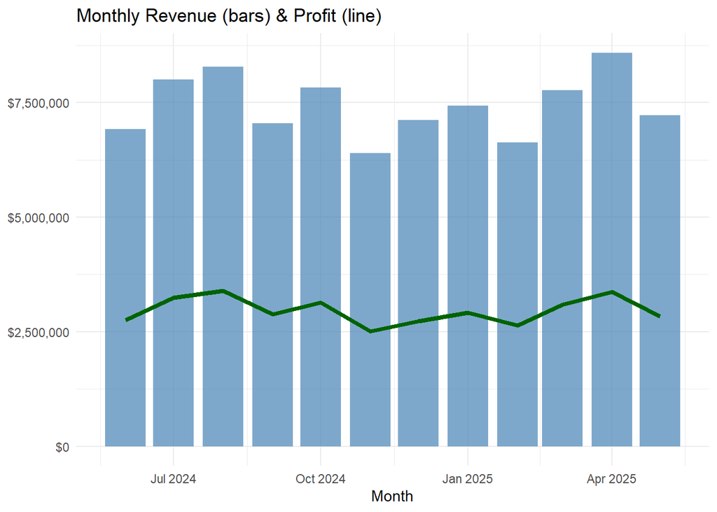

```r
# Monthly sales
monthly_sales <- sales |>
  mutate(posting_date = mdy(posting_date),   # convert to Date
         month = floor_date(posting_date, "month")) |>
  filter(posting_date > as.Date("2024-05-31")) |> # May has hardly anything and doesn't add to the viz

  group_by(month) |>
  summarise(
    revenue = sum(nsi_dead_net, na.rm = TRUE),
    profit = sum(gross_profit_dead_net, na.rm = TRUE),
    profit_margin = profit / revenue * 100,
    .groups = "drop"
  )

ggplot(monthly_sales, aes(x = month)) +
  geom_col(aes(y = revenue), fill = "steelblue", alpha = 0.7) +
  geom_line(aes(y = profit), color = "darkgreen", size = 1.5) +
  scale_y_continuous(labels = dollar) +
  labs(title = "Monthly Revenue (bars) & Profit (line)", x = "Month", y = NULL) +
  theme_minimal()
```

- Revenue and profits don’t drastically change across months.

## 6.2 Customer Value Analysis

- Which segments of customers contribute most to overall revenue and profit, and how concentrated is revenue among top-tier customers?

**🖱️👆 Click to Show Code**

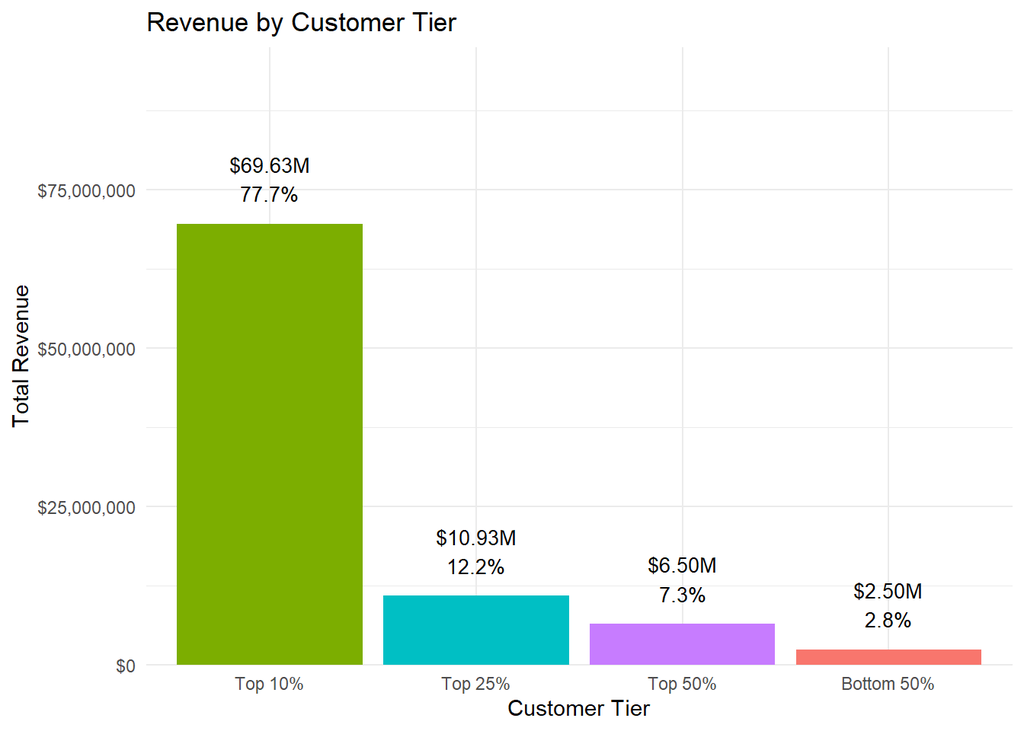

```r
# Customer-level metrics
# this lets us see where the money is coming from for orders
customer_value <- sales |>
  group_by(customer_id) |>
  summarise(
    total_revenue = sum(nsi_dead_net, na.rm = TRUE),
    total_profit = sum(gross_profit_dead_net, na.rm = TRUE),
    num_transactions = n(),
    unique_products = n_distinct(material_id),
    avg_transaction_value = mean(nsi_dead_net, na.rm = TRUE),
    .groups = "drop"
  ) |>

  # Now lets group the customers into tiers based on their revenue
  mutate(
    customer_tier = case_when(
      total_revenue >= quantile(total_revenue, 0.9) ~ "Top 10%",
      total_revenue >= quantile(total_revenue, 0.75) ~ "Top 25%",
      total_revenue >= quantile(total_revenue, 0.5) ~ "Top 50%",
      TRUE ~ "Bottom 50%"
    )
  )

# Customer tier distribution
tier_summary <- customer_value |>
  group_by(customer_tier) |>
  summarise(
    customers = n(),
    revenue = sum(total_revenue),
    profit = sum(total_profit),
    .groups = "drop"
  ) |>
  mutate(
    pct_customers = customers / sum(customers) * 100,
    pct_revenue = revenue / sum(revenue) * 100
  )

ggplot(tier_summary, aes(x = reorder(customer_tier, -revenue), y = revenue, fill = customer_tier)) +
  geom_col(show.legend = FALSE) +
  geom_text(aes(label = paste0(dollar(revenue, scale = 1e-6, suffix = "M"), "\n",
                               round(pct_revenue, 1), "%")), vjust = -0.5, size = 3.5) +
  scale_y_continuous(labels = dollar, expand = expansion(mult = c(0, 0.4))) +
  labs(title = "Revenue by Customer Tier", x = "Customer Tier", y = "Total Revenue") +
  theme_minimal()
```

- Almost **80%** of all revenue comes from the top 10% of customers.
- If we can focus on cart abandonment for these customers it will have the most impact on sales.
- The bottom 50% of customers produces only 2.8% of revenue.

## 6.3 Product Revenue

- Which products produce the most revenue?

**🖱️👆 Click to Show Code**

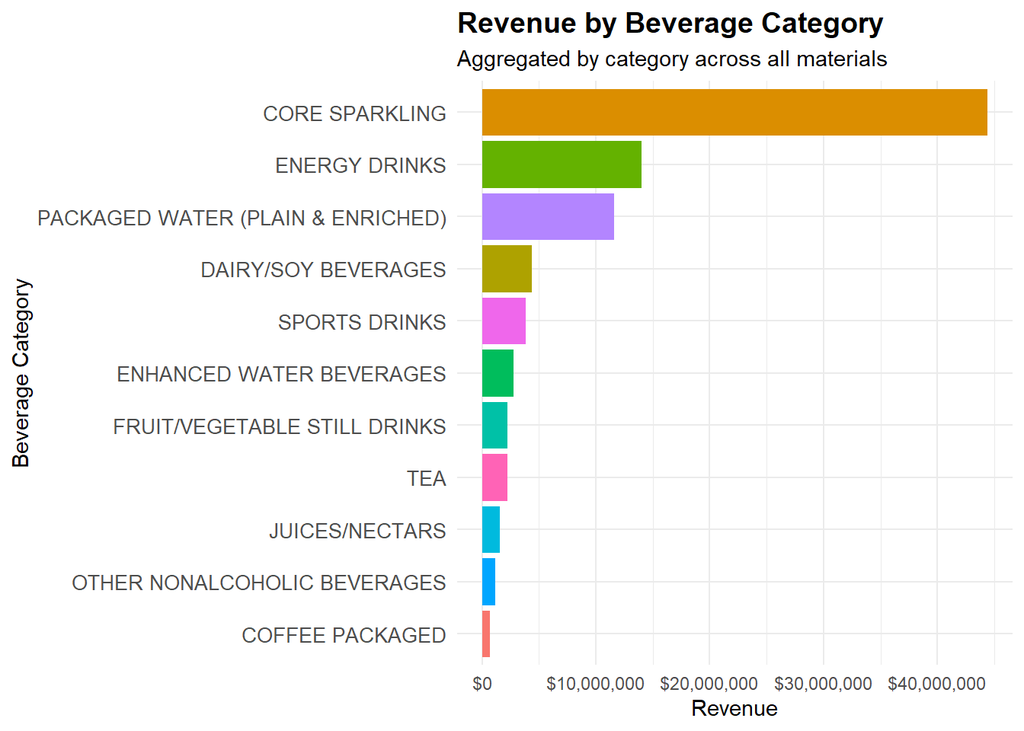

```r
# Merge product info
sales_material <- sales |>
  left_join(material, by = "material_id") |>
  filter(!is.na(bev_cat_desc), # Filter out the NA and "" categories
          bev_cat_desc != "")

# Category-level metrics
category_performance <- sales_material |>
  group_by(bev_cat_desc) |>
  summarise(
    revenue = sum(nsi_dead_net, na.rm = TRUE),
    profit = sum(gross_profit_dead_net, na.rm = TRUE),
    volume = sum(physical_volume, na.rm = TRUE),
    transactions = n(),
    customers = n_distinct(customer_id),
    .groups = "drop"
  ) |>
  mutate(profit_margin = profit / revenue * 100)

# Plot by Category
ggplot(category_performance, aes(x = reorder(bev_cat_desc, revenue), y = revenue, fill = bev_cat_desc)) +
  geom_col(show.legend = FALSE) +
  coord_flip() +
  scale_y_continuous(labels = scales::dollar) +
  labs(
    title = "Revenue by Beverage Category",
    subtitle = "Aggregated by category across all materials",
    x = "Beverage Category",
    y = "Revenue"
  ) +
  theme_minimal() +
  theme(
    plot.title = element_text(face = "bold", size = 14),
    axis.text.y = element_text(size = 10)
  )
```

- Similar to the order quantities, the “Core Sparkling” group produced the most revenue, outpacing other categories by over $20 million.

# 7 📊 Results

## 7.1 Overview

The datasets we have been given for this project provide a detailed look at how Swire creates revenue by providing customers with many options to place orders and receive products. We wish that we had more time to finish creating the target variable, but the complexity of the data wrangling task didn’t allow us to explore this yet. We look forward to exploring how cart abandonment relates to the analysis we have done in this notebook.

## 7.2 Data Quality Issues

- While some of the data was usable and didn’t require much cleaning there were some tables that raised concerns:
  - There was some inconsistency with frequency labeling across tables.
  - Inconsistency with distribution modes across tables with some only existing in 1 table and not existing in others.
  - Some visit plan anchor dates had overlapping snapshot dates with other anchor dates for the same customer.
  - Time zones were inconsistent across tables and had to be matched to local time for analysis.
  - There were some null and “” values in the categories for some of the products in the materials table.

## 7.3 Key Patterns and Insights

- As we explored the data, we observed that the MyCoke360 platform has started to become more popular as more customers transition from other methods like sales reps and call centers.
- While a small subset of customers uses mobile (14%), the majority (85%) of users interact with the website using their desktop. This signifies the importance of optimizing the desktop experience to avoid cart abandonment there.
- The “core sparkling” product category accounts for most of the order volume and revenue for the business.
- Order volume and revenue is constant by month throughout the year with small variation.
- Almost 80% of total revenue is produced by 10% of the customers. If we can focus on the cart abandonment trends in this group, we will be able to make the most impact on company profits.